# *RMeDPower2*: helping design and analyses of data from repeated measures experiments

### Gene expression associations with genotype

We will now estimate the association of the expression levels of the Snhg11 gene with genotype among cells in cluster 7 in the same data set. We will now load the raw counts for this gene and create the relevant RMeDesign, ProbabilityModel and PowerParams objects.

```r
template_dir <- "~/Dropbox (Gladstone)/calcPower f1000_manuscript/Final_paper_materials/Revisions/input_templates/single_cell_data/gene_expression_with_genotype/"

data <- read.csv(paste0(template_dir, "raw_counts_Snhg11_gene_cluster_7_snRNAseq_Koutsodendris_et_al_2023.csv"), header = T)
# data %<>% mutate(genotype = gsub(" ", "-", genotype))
# data %>% write.csv(., paste0(template_dir, "raw_counts_Snhg11_gene_cluster_7_snRNAseq_Koutsodendris_et_al_2023.csv"), row.names = F)
head(data)
```

```
##    y    orig.ident nCount_RNA nFeature_RNA percent.mt sample_number
## 1 20 SeuratProject       2878         1716 0.03474635           S10
## 2  6 SeuratProject       9350         3682 0.05347594           S10
## 3 22 SeuratProject       2949         1735 0.03390980           S10
## 4 12 SeuratProject       4529         2494 0.04415986           S10
## 5 14 SeuratProject       3044         1866 0.03285151           S10
## 6  9 SeuratProject      10636         3957 0.03760812           S10
##   mouse_number genotype sex Cre ApoE      dob age_perfused date_perfused
## 1          154 PS19-fE4   F   - E4/4 10/30/19         10.3        9/7/20
## 2          154 PS19-fE4   F   - E4/4 10/30/19         10.3        9/7/20
## 3          154 PS19-fE4   F   - E4/4 10/30/19         10.3        9/7/20
## 4          154 PS19-fE4   F   - E4/4 10/30/19         10.3        9/7/20
## 5          154 PS19-fE4   F   - E4/4 10/30/19         10.3        9/7/20
## 6          154 PS19-fE4   F   - E4/4 10/30/19         10.3        9/7/20
##   date_of_nuclear_isolation nCount_SCT nFeature_SCT SCT_snn_res.0.7
```

[output cut: 20 more lines]

```r
design <- readDesign(paste0(template_dir,"design_gene_expression.json"))
print(design)
```

```
## An object of class "RMeDesign"
## Slot "response_column":
## [1] "y"
##
## Slot "covariate":
## [1] "sex"
##
## Slot "condition_column":
## [1] "genotype"
##
## Slot "condition_is_categorical":
## [1] TRUE
##
## Slot "experimental_columns":
## [1] "sample_number"
##
## Slot "crossed_columns":
## NULL
##
## Slot "total_column":
## [1] "library_size"
##
## Slot "outlier_alpha":
## [1] 0.05
##
## Slot "na_action":
## [1] "complete"
##
## Slot "include_interaction":
## [1] NA
##
## Slot "random_slope_variable":
## NULL
##
## Slot "covariate_is_categorical":
## [1] NA
```

```r
design@covariate_is_categorical <- TRUE
design@include_interaction <- FALSE

model <- readProbabilityModel(paste0(template_dir,"prob_model.json"))
print(model)
```

```
## An object of class "ProbabilityModel"
## Slot "error_is_non_normal":
## [1] TRUE
##
## Slot "family_p":
## [1] "negative_binomial"
```

```r
power_param <- readPowerParams(paste0(template_dir,"power_param.json"))
print(power_param)
```

```
## An object of class "PowerParams"
## Slot "target_columns":
## [1] "sample_number"
##
## Slot "power_curve":
## [1] 1
##
## Slot "nsimn":
## [1] 10
##
## Slot "levels":
## [1] 1
##
## Slot "max_size":
## [1] 1
##
## Slot "alpha":
## [1] 0.05
##
## Slot "breaks":
## NULL
##
## Slot "effect_size":
## NULL
##
## Slot "icc":
## NULL
```

Note, we will assume the underlying probability distribution for the counts is negative binomial and will control for differences in the sequencing depths or the total reads each cell receives using `library_size`.

Diagnosis of the data and the model

```r
diagnose_res <- diagnoseDataModel(data, design, model)
```

To identify all the models fit to the data. There were outliers identified so two models were fit in the natural scale.

```r
print(diagnose_res$models)
```

```
## [1] "Natural scale"             "Natural scale wo outliers"
```

Let us look the basic QC plots for the models fit in the natural scale of the responses.

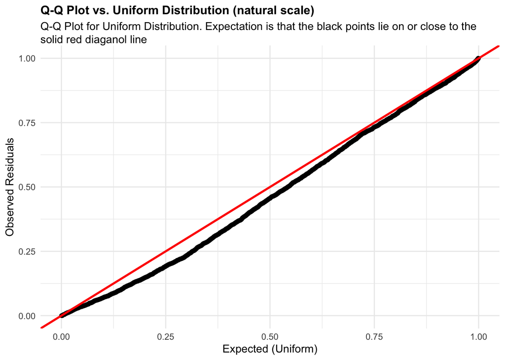

```r
plots <- diagnose_res$plots_info$natural_scale$plots
captions <- diagnose_res$plots_info$natural_scale$captions

for (i in seq_along(plots)) {
  print(plots[[i]])
  cat(sprintf("\n\n\n**Figure %d:** %s\n\n", plot_no, names(plots)[i]))
  plot_no <- plot_no + 1
}
```

**Figure 20:** residuals_QQ

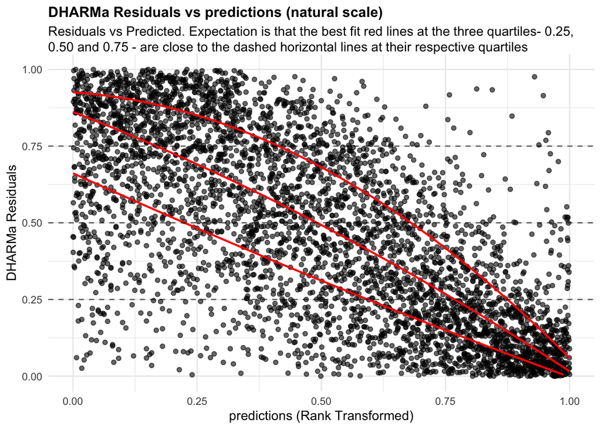

**Figure 21:** residuals_vs_predicted

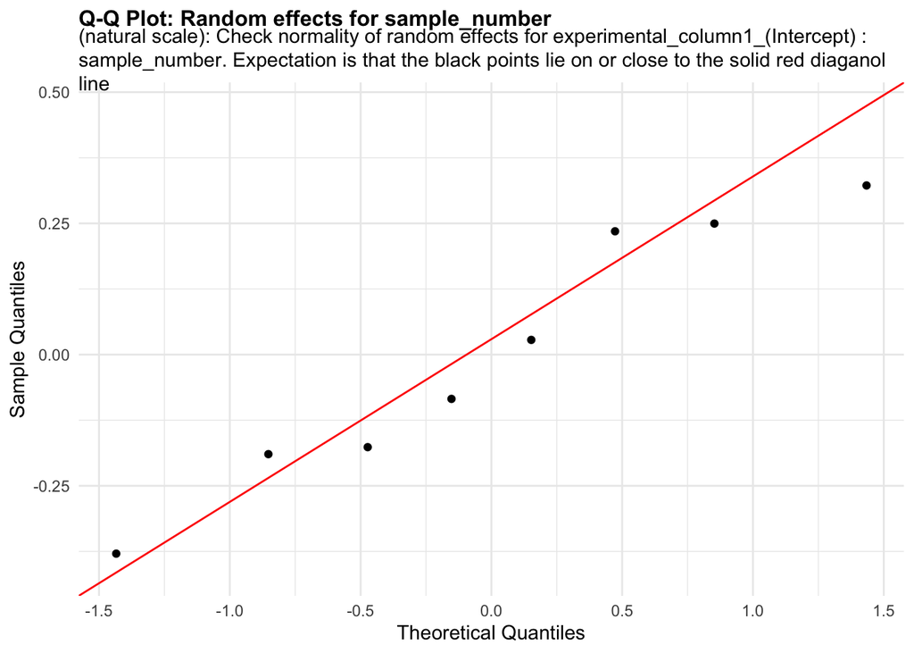

**Figure 22:** random_effects_QQ_1

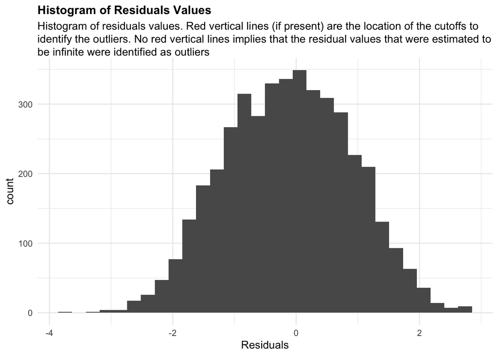

**Figure 23:** residuals_histogram

Let us also now look at the QC plots after removing the identified outliers

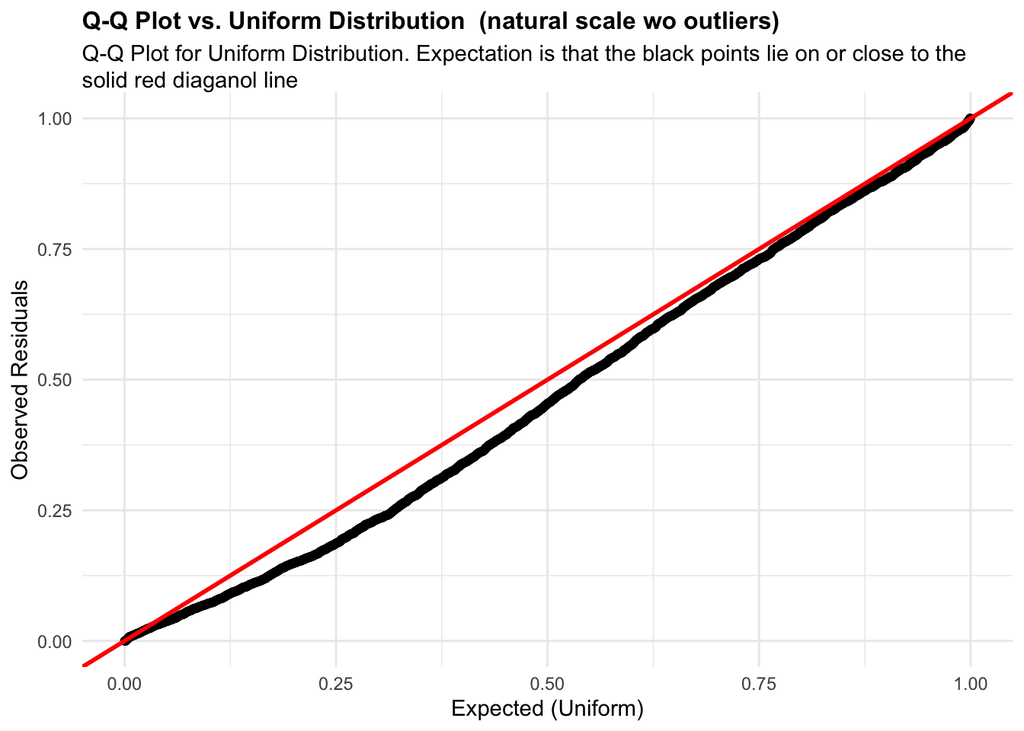

```r
plots <- diagnose_res$plots_info$natural_scale_wo_outliers$plots
captions <- diagnose_res$plots_info$natural_scale_wo_outliers$captions

for (i in seq_along(plots)) {
  print(plots[[i]])
  cat(sprintf("\n\n\n**Figure %d:** %s\n\n", plot_no, names(plots)[i]))
  plot_no <- plot_no + 1
}
```

**Figure 24:** residuals_QQ

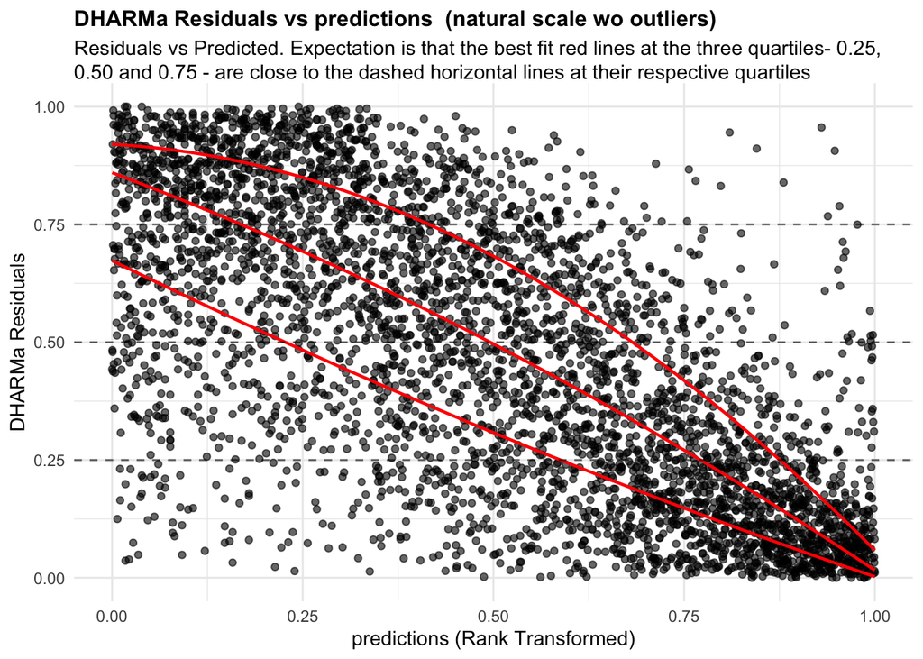

**Figure 25:** residuals_vs_predicted

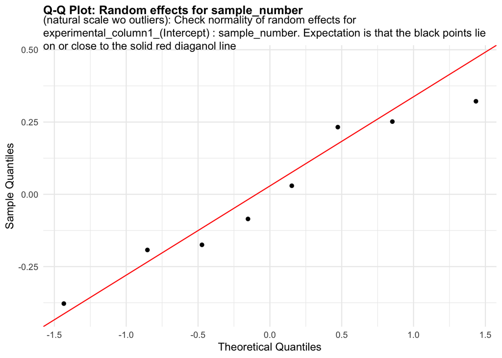

**Figure 26:** random_effects_QQ_1

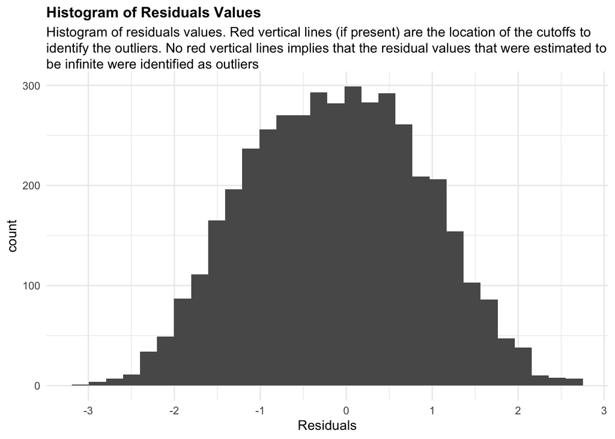

**Figure 27:** residuals_histogram

We don’t see a good fit to the assumption of negative binomial distribution based on the Quantile-Quantile plots suggesting that GLMM models for single cell RNA-seq data, even though they have been proposed as alternatives to dealing with the issue of pseudo-replication, are not good models to assess for differential expression.

Estimate log-fold change of the Snhg11 gene with genotype.

```r
estimate_res <- getEstimatesOfInterest(data, design, model)
```

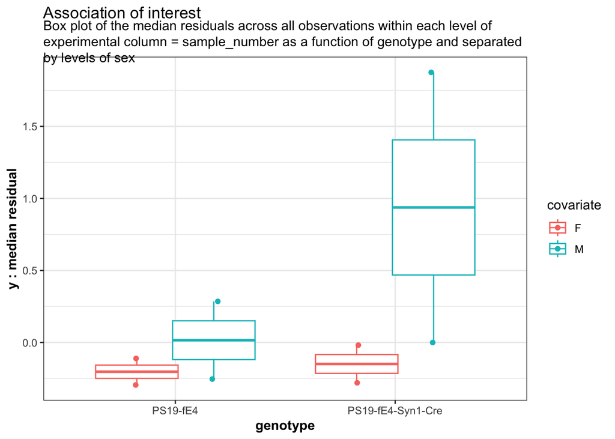

```r
print(estimate_res[[1]])
```

```
## Generalized linear mixed model fit by maximum likelihood (Laplace
##   Approximation) [glmerMod]
##  Family: Negative Binomial(4.914)  ( log )
## Formula:
## response_column ~ condition_column + covariate + (1 | experimental_column1) +
##     offset(log(total_column))
##    Data: fixed_global_variable_data
##
##       AIC       BIC    logLik -2*log(L)  df.resid
##   28790.0   28821.9  -14390.0   28780.0      4297
##
## Scaled residuals:
##     Min      1Q  Median      3Q     Max
## -1.8485 -0.7485 -0.1820  0.5882  5.4549
##
## Random effects:
##  Groups               Name        Variance Std.Dev.
##  experimental_column1 (Intercept) 0.07378  0.2716
## Number of obs: 4302, groups:  experimental_column1, 8
##
## Fixed effects:
##                                   Estimate Std. Error z value Pr(>|z|)
## (Intercept)                        -5.1736     0.1756 -29.460   <2e-16 ***
## condition_columnPS19-fE4-Syn1-Cre   0.4622     0.2280   2.027   0.0426 *
## covariateM                          0.1356     0.2335   0.581   0.5616
## ---
## Signif. codes:  0 '***' 0.001 '**' 0.01 '*' 0.05 '.' 0.1 ' ' 1
##
## Correlation of Fixed Effects:
##             (Intr) c_PS19
## c_PS19-E4-S -0.450
## covariateM  -0.588 -0.076
```

We can also perform a power analyses to detect a log(2) fold-change in this gene.

```r
power_param@effect_size <- log(2)
power_res <- calculatePower(data, design, model, power_param)
```

```
##
## [1] "_________________________________Effect size of the condition_column is now 0.693147180559945"
```

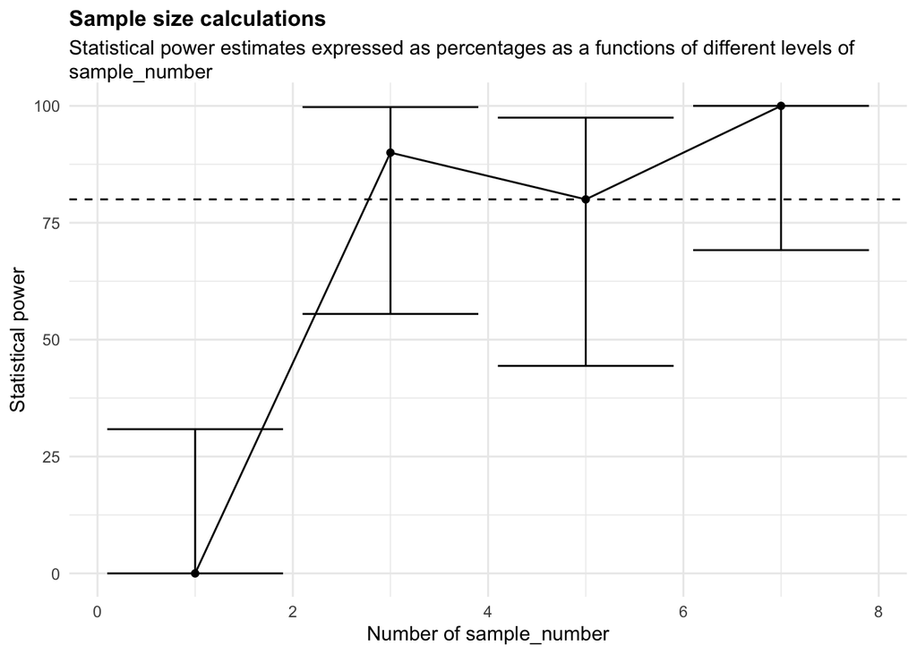

```r
print(power_res$plots)
```

## Behavior assays

```r
template_dir <- "~/Dropbox (Gladstone)/calcPower f1000_manuscript/Final_paper_materials/Revisions/input_templates/behavior_data/"
data <- read.csv(paste0(template_dir, "MWM_data.csv"), header = T)
# data %<>% mutate(trial = sapply(Trial, function(x) gsub("LATENCY_", "", x) %>% as.numeric())) %>% select(-Trial)
# data %>% write.csv(paste0(template_dir, "MWM_data.csv"), row.names = F)
design <- readDesign(paste0(template_dir,"design_behavior.json"))
design@covariate <- "trial"
design@covariate_is_categorical <- FALSE
design@include_interaction <- FALSE
model <- readProbabilityModel(paste0(template_dir,"prob_model.json"))
power_param <- readPowerParams(paste0(template_dir,"power_param.json"))
```

```r
diagnose_res <- diagnoseDataModel(data, design, model)
```

```
## [1] "No outlier detected from the raw Data"
## [1] "No outlier detected from the raw Data"
```

To identify all the models fit to the data

```r
print(diagnose_res$models)
```

```
## [1] "Natural scale"         "Log scale"             "Log scale wo outliers"
```

Let us look the basic QC plots for the models fit in the natural scale of the responses.

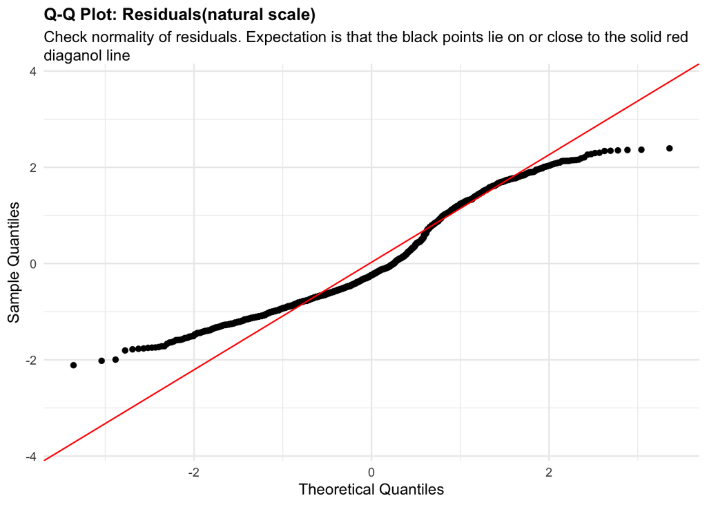

```r
plots <- diagnose_res$plots_info$natural_scale$plots
captions <- diagnose_res$plots_info$natural_scale$captions

for (i in seq_along(plots)) {
  print(plots[[i]])
  cat(sprintf("\n\n\n**Figure %d:** %s\n\n", plot_no, names(plots)[i]))
  plot_no <- plot_no + 1
}
```

**Figure 28:** residuals_QQ

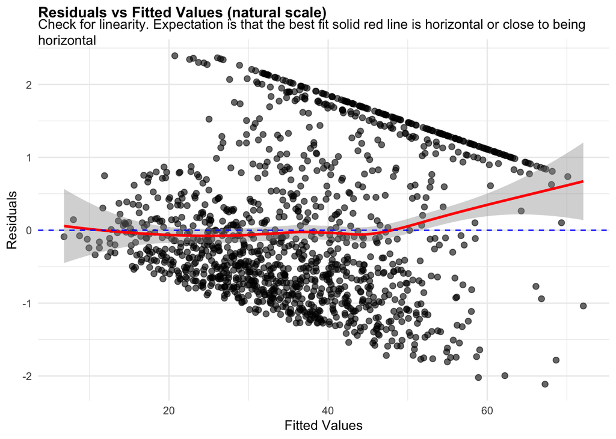

**Figure 29:** residuals_vs_fitted

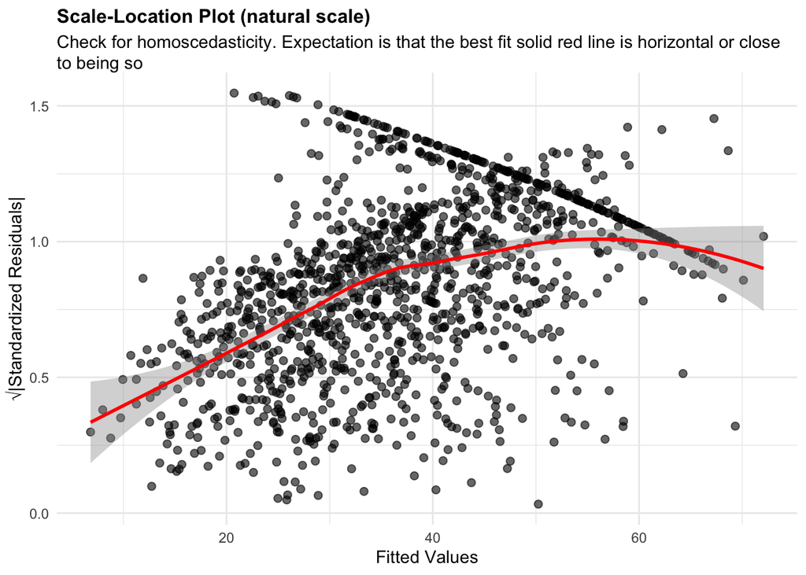

**Figure 30:** residuals_homoscedasticity

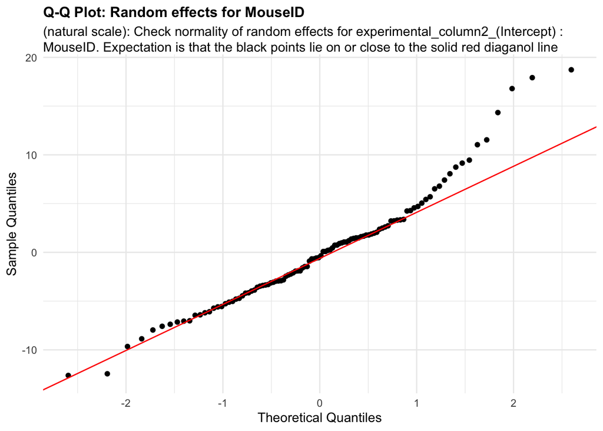

**Figure 31:** random_effects_QQ_1

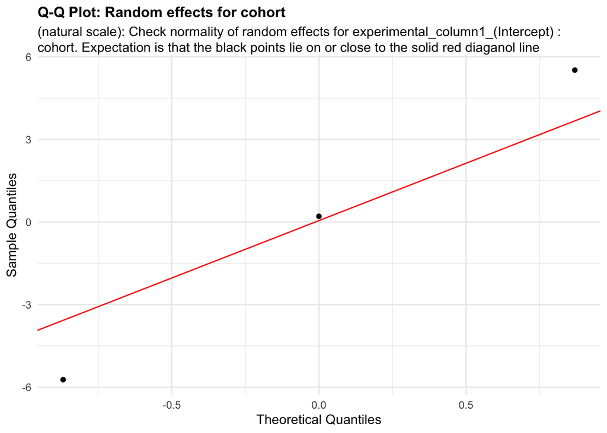

**Figure 32:** random_effects_QQ_2

Now, let us look at the same set of QC plots for models on the log-transformed responses.

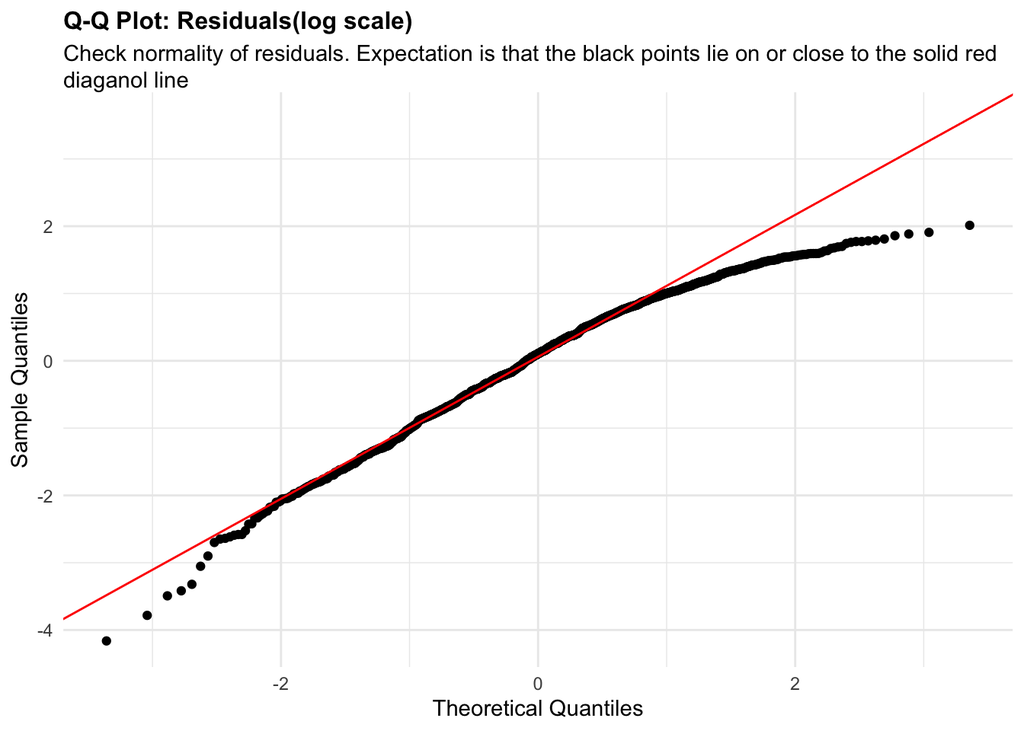

```r
plots <- diagnose_res$plots_info$log_scale$plots
captions <- diagnose_res$plots_info$log_scale$captions

for (i in seq_along(plots)) {
  print(plots[[i]])
  cat(sprintf("\n\n\n**Figure %d:** %s\n\n", plot_no, names(plots)[i]))
  plot_no <- plot_no + 1
}
```

**Figure 33:** residuals_QQ

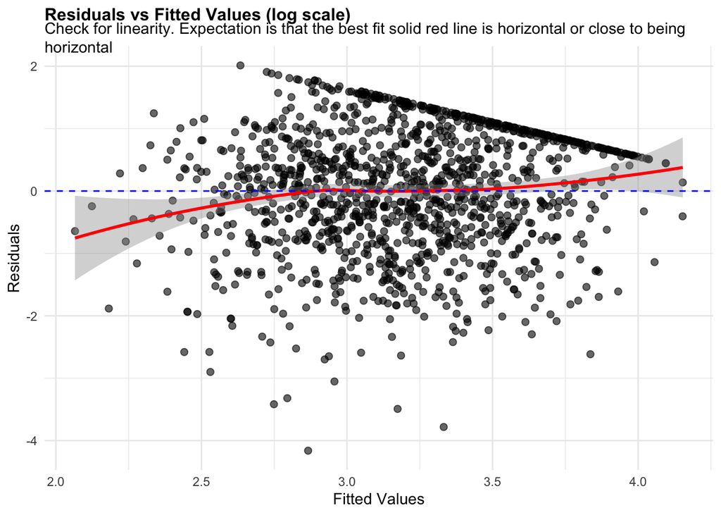

**Figure 34:** residuals_vs_fitted

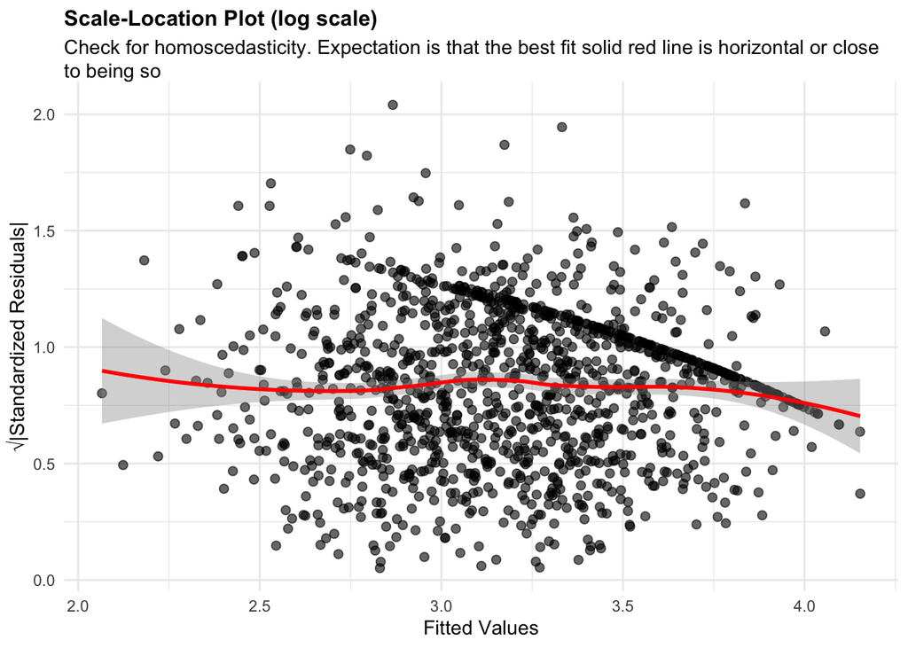

**Figure 35:** residuals_homoscedasticity

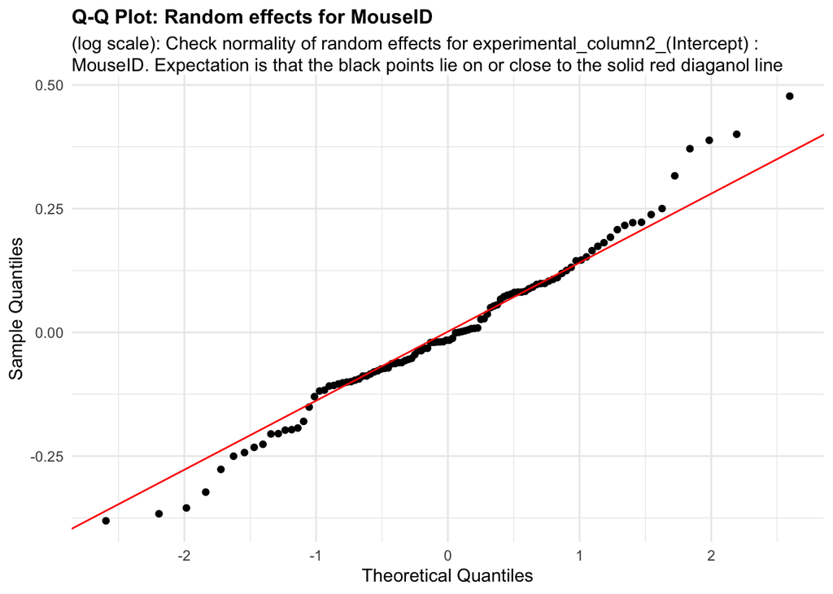

**Figure 36:** random_effects_QQ_1

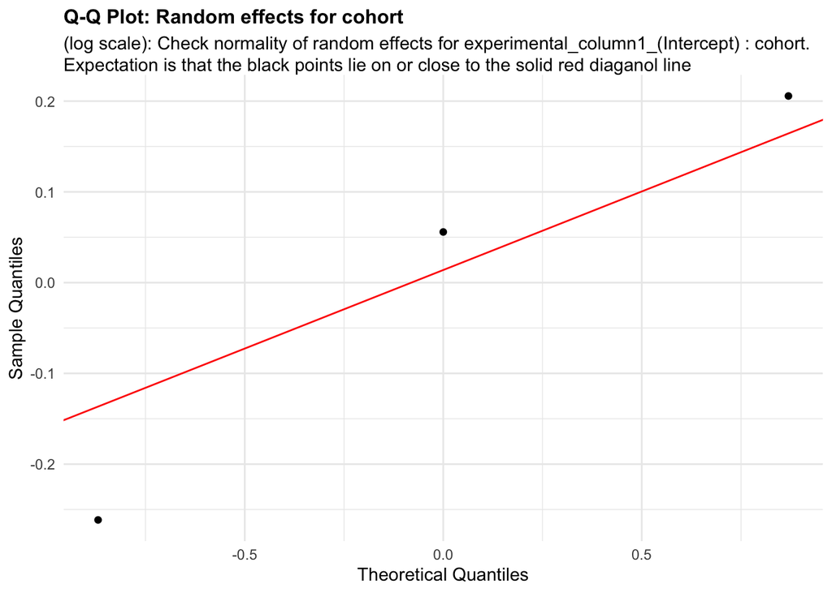

**Figure 37:** random_effects_QQ_2

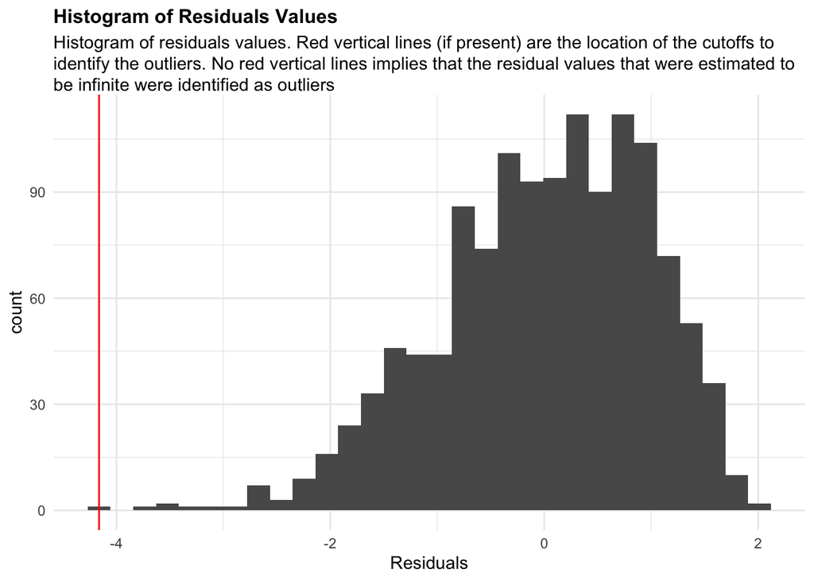

**Figure 38:** residuals_histogram Now, let us look at the same set of QC plots for models on the log-transformed responses without the identified outliers in the log-transformed model

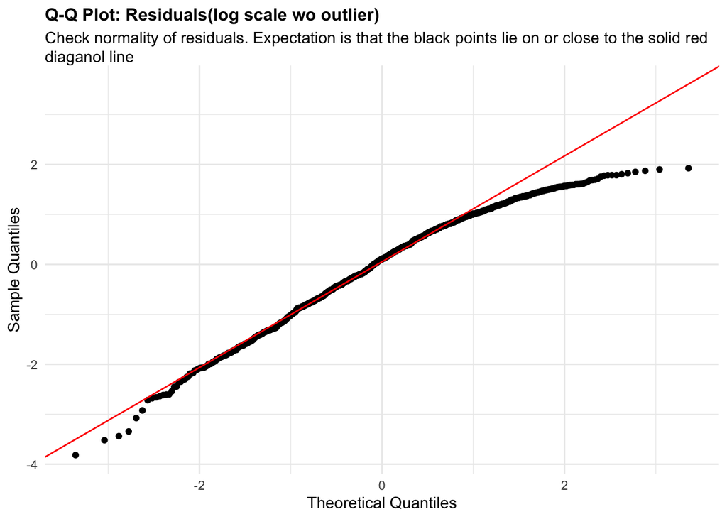

```r
plots <- diagnose_res$plots_info$log_scale_wo_outliers$plots
captions <- diagnose_res$plots_info$log_scale_wo_outliers$captions

for (i in seq_along(plots)) {
  print(plots[[i]])
  cat(sprintf("\n\n\n**Figure %d:** %s\n\n", plot_no, names(plots)[i]))
  plot_no <- plot_no + 1
}
```

**Figure 39:** residuals_QQ

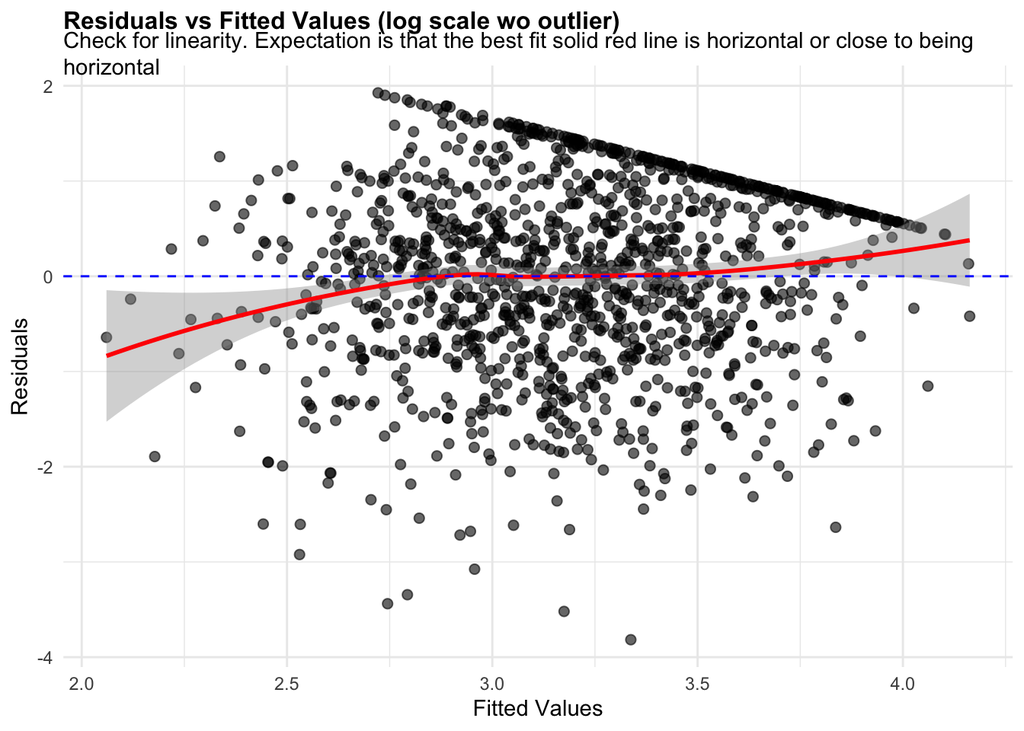

**Figure 40:** residuals_vs_fitted

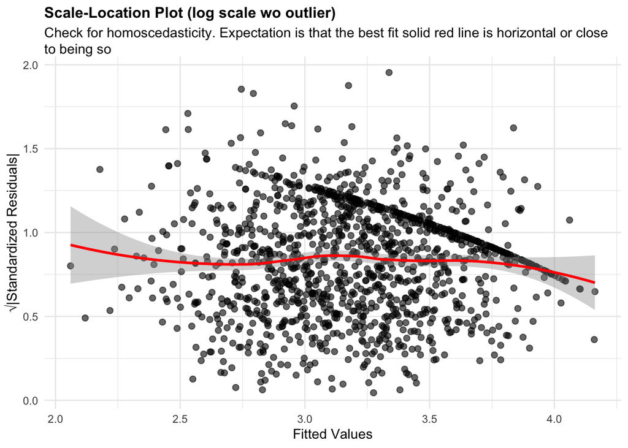

**Figure 41:** residuals_homoscedasticity

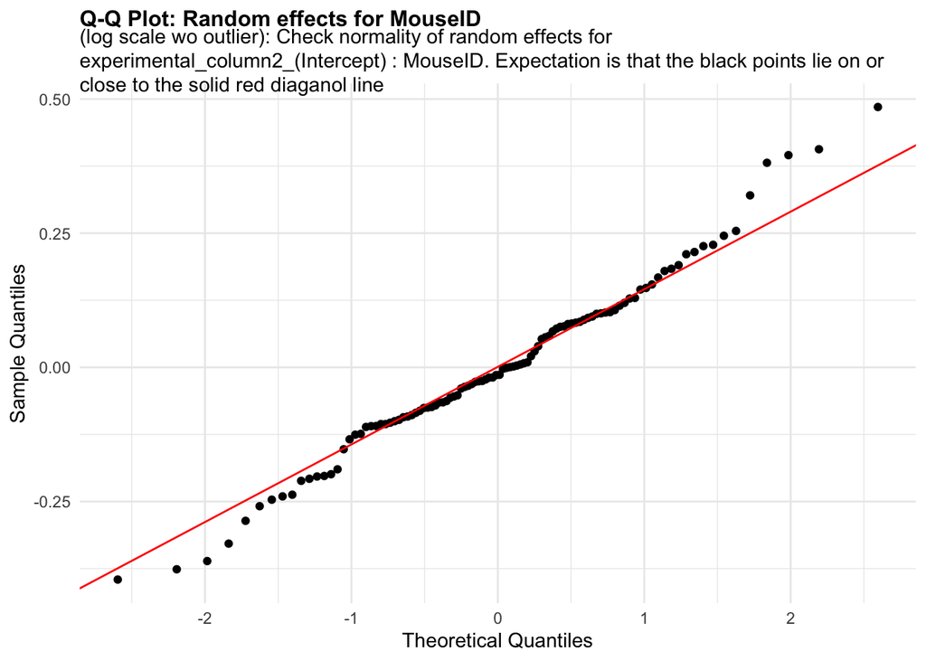

**Figure 42:** random_effects_QQ_1

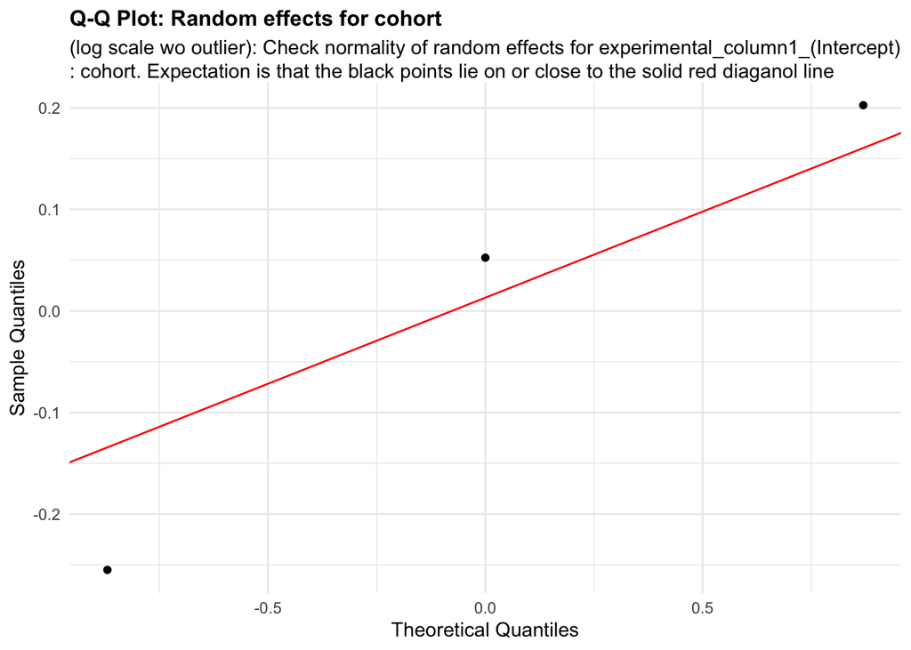

**Figure 43:** random_effects_QQ_2

The code also outputs Cook’s distance measures for each cohort and mouse that is intended to capture how influential each of these were in determining the final parameter estimates in the LMM model.

```r
##see which experimental columns correspond to which variable
print(design@experimental_columns)
## for each experimental column
for(i in 1:length(diagnose_res$models)) {
  for(j in 1:length(design@experimental_columns)){
    print(paste0("Cooks distance estimates for model ", diagnose_res$models[i], " and experimental factor = ", design@experimental_columns[j]))
    print(diagnose_res$cooks_result[[i]][[j]])
  }
}
```

[output not shown]

There aren’t any obvious outliers in any of these models for cohort or mice.

Based on the above plots, it seems like the log transformed versions of the latency responses better fit the model assumptions. Therefore using these transformed responses we will estimate and visualize our parameter of interest.

```r
data_update <- diagnose_res$Data_updated
design_update <- design
design_update@response_column %<>% paste0(., "_logTransformed_noOutlier")
estimate_res <- getEstimatesOfInterest(data_update, design_update, model)
```

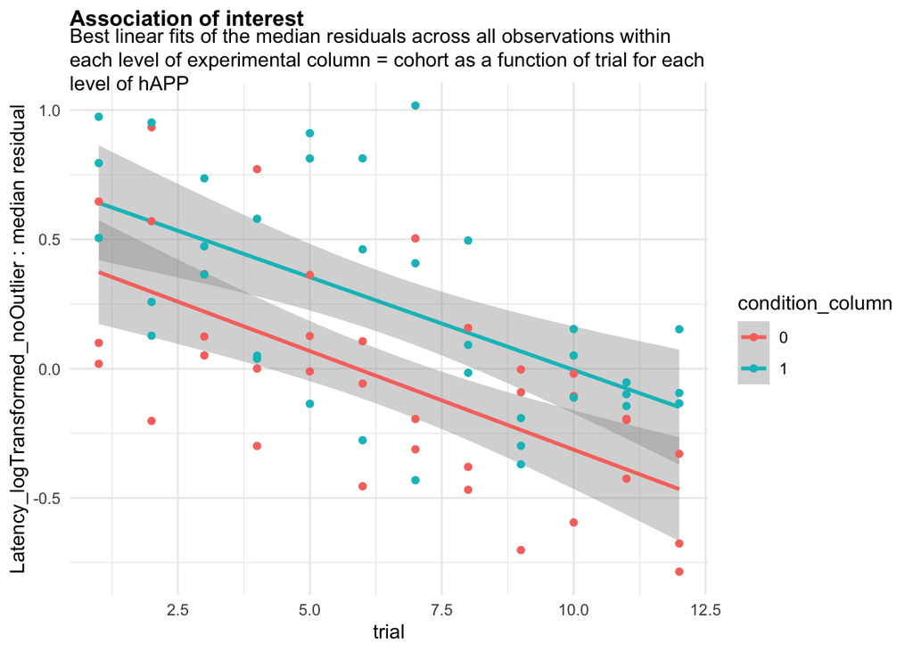

```r
print(estimate_res[[1]])
```

```
## Linear mixed model fit by REML. t-tests use Satterthwaite's method [
## lmerModLmerTest]
## Formula:
## response_column ~ condition_column + covariate + (1 | experimental_column1) +
##     (1 | experimental_column2)
##    Data: fixed_global_variable_data
##
## REML criterion at convergence: 3430.9
##
## Scaled residuals:
##     Min      1Q  Median      3Q     Max
## -3.8168 -0.6592  0.1087  0.7697  1.9260
##
## Random effects:
##  Groups               Name        Variance Std.Dev.
##  experimental_column2 (Intercept) 0.06004  0.2450
##  experimental_column1 (Intercept) 0.05800  0.2408
##  Residual                         0.81359  0.9020
## Number of obs: 1271, groups:
## experimental_column2, 106; experimental_column1, 3
##
## Fixed effects:
##                     Estimate Std. Error         df t value Pr(>|t|)
## (Intercept)        3.416e+00  1.554e-01  2.722e+00  21.983 0.000381 ***
## condition_column1  3.716e-01  6.992e-02  1.022e+02   5.315 6.29e-07 ***
## covariate         -5.878e-02  7.328e-03  1.164e+03  -8.022 2.52e-15 ***
## ---
## Signif. codes:  0 '***' 0.001 '**' 0.01 '*' 0.05 '.' 0.1 ' ' 1
##
## Correlation of Fixed Effects:
##             (Intr) cndt_1
## cndtn_clmn1 -0.230
## covariate   -0.307  0.000
```

```r
#print(estimate_res[[2]]$plots)
```

We will also perform sample-size calculations for the number of mice needed per cohort.

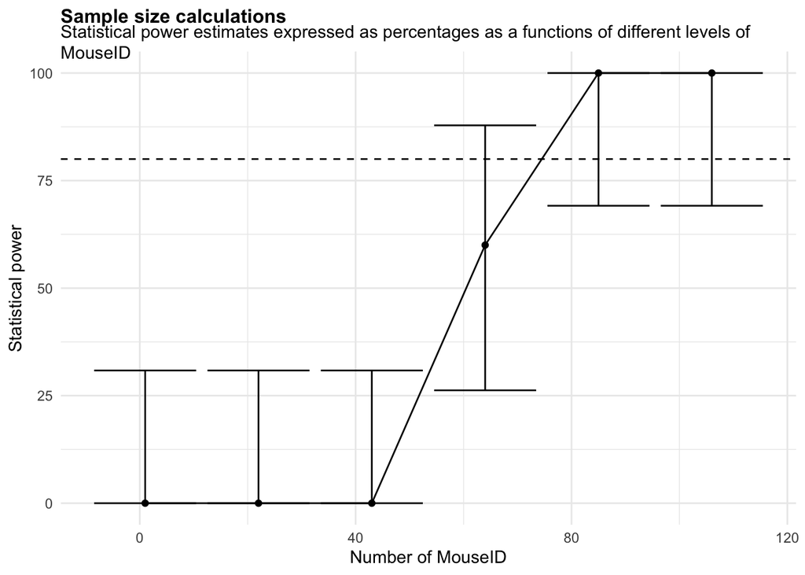

```r
power_param@target_columns <- "MouseID"
power_res <- calculatePower(data_update, design_update, model, power_param)
print(power_res$plots)
```

## Brain electrical signal assays

Patch clamp is a technique that can be used to measure membrane action potential in excitable cells like neurons. We will work with (simulated) data from two sets of mice - one representing a Alzheimer’s Disease model (hAPP) and the other representing control or wild-type mice. In each of these mice, multiple brain tissue slices are isolated and the membrane action potential for at least one neuronal cell in each slice is recorded.

```r
template_dir <- "~/Dropbox (Gladstone)/calcPower f1000_manuscript/Final_paper_materials/Revisions/input_templates/electrical_patch_clamp_data/"
data <- read.csv(paste0(template_dir, "patch_clamp_data.csv"), header = T)
head(data)
```

```
##   negative_action_potential_mV    Mice Genotype    Sex slice_number
## 1                     56.23547 Mouse_1     hAPP   Male            1
## 2                     47.89597 Mouse_3     hAPP   Male            1
## 3                     56.20910 Mouse_3     hAPP   Male            2
## 4                     53.14394 Mouse_9     hAPP Female            1
## 5                     53.67793 Mouse_9     hAPP Female            1
## 6                     61.21780 Mouse_9     hAPP Female            1
```

```r
design <- readDesign(paste0(template_dir,"design_patch_clamp.json"))
print(design)
```

```
## An object of class "RMeDesign"
## Slot "response_column":
## [1] "negative_action_potential_mV"
##
## Slot "covariate":
## NULL
##
## Slot "condition_column":
## [1] "Genotype"
##
## Slot "condition_is_categorical":
## [1] TRUE
##
## Slot "experimental_columns":
## [1] "Mice"         "slice_number"
##
## Slot "crossed_columns":
## NULL
##
## Slot "total_column":
## NULL
##
## Slot "outlier_alpha":
## [1] 0.05
##
## Slot "na_action":
## [1] "complete"
##
## Slot "include_interaction":
## [1] NA
##
## Slot "random_slope_variable":
## NULL
##
## Slot "covariate_is_categorical":
## [1] NA
```

```r
model <- readProbabilityModel(paste0(template_dir,"prob_model.json"))
print(model)
```

```
## An object of class "ProbabilityModel"
## Slot "error_is_non_normal":
## [1] FALSE
##
## Slot "family_p":
## NULL
```

```r
power_param <- readPowerParams(paste0(template_dir,"power_param.json"))
print(power_param)
```

```
## An object of class "PowerParams"
## Slot "target_columns":
## [1] "Mice"
##
## Slot "power_curve":
## [1] 1
##
## Slot "nsimn":
## [1] 10
##
## Slot "levels":
## [1] 1
##
## Slot "max_size":
## [1] 1
##
## Slot "alpha":
## [1] 0.05
##
## Slot "breaks":
## NULL
##
## Slot "effect_size":
## NULL
##
## Slot "icc":
## NULL
```

We will now evaluate the model.

```r
diagnose_res <-diagnoseDataModel(data, design, model)
```

```
## [1] "No outlier detected from the raw Data"
```

```
## [1] "No outlier detected from the raw Data"
```

To identify all the models fit to the data

```r
print(diagnose_res$models)
```

```
## [1] "Natural scale"             "Natural scale wo outliers"
## [3] "Log scale"
```

We see that three models were fit to this data - one in the natural scale of negative_action_potential_mV, other in the natural scale without outliers and the last one in log scale.

Let us look the basic QC plots for the models fit in the natural scale of the responses.

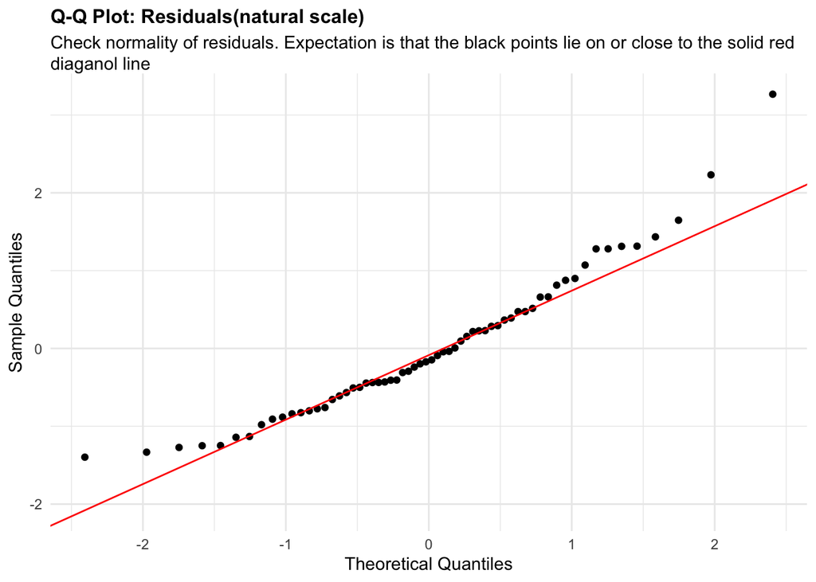

```r
plots <- diagnose_res$plots_info$natural_scale$plots
captions <- diagnose_res$plots_info$natural_scale$captions

for (i in seq_along(plots)) {
  print(plots[[i]])
  cat(sprintf("\n\n\n**Figure %d:** %s\n\n", plot_no, names(plots)[i]))
  plot_no <- plot_no + 1
}
```

**Figure 44:** residuals_QQ

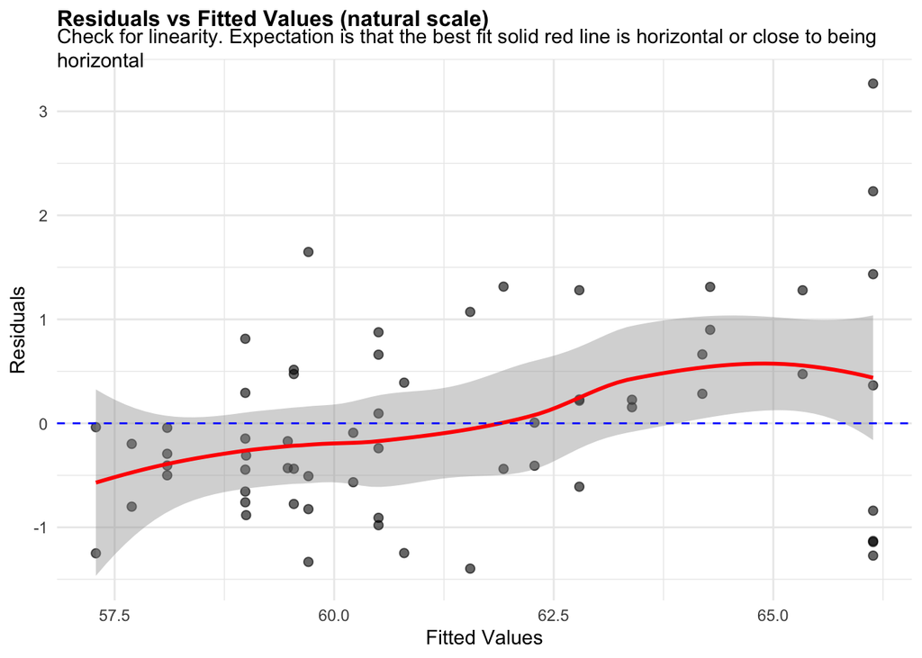

**Figure 45:** residuals_vs_fitted

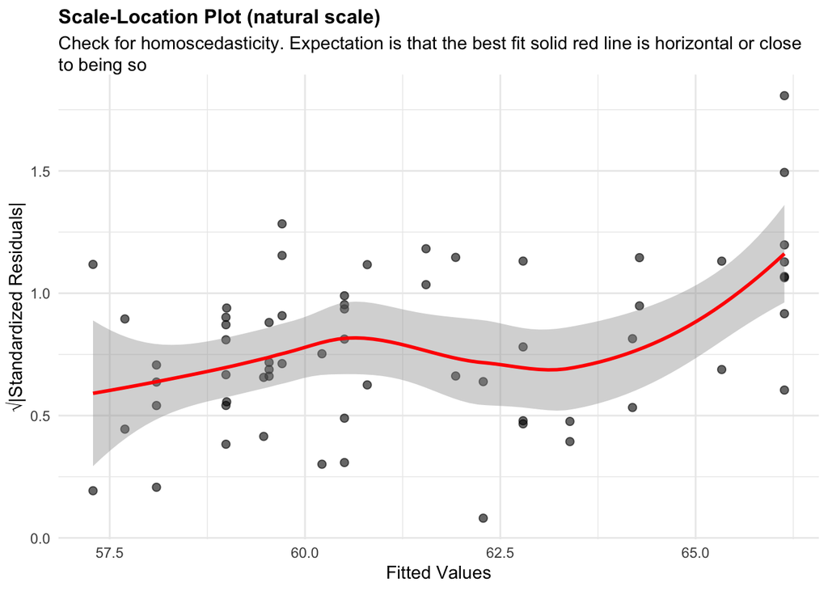

**Figure 46:** residuals_homoscedasticity

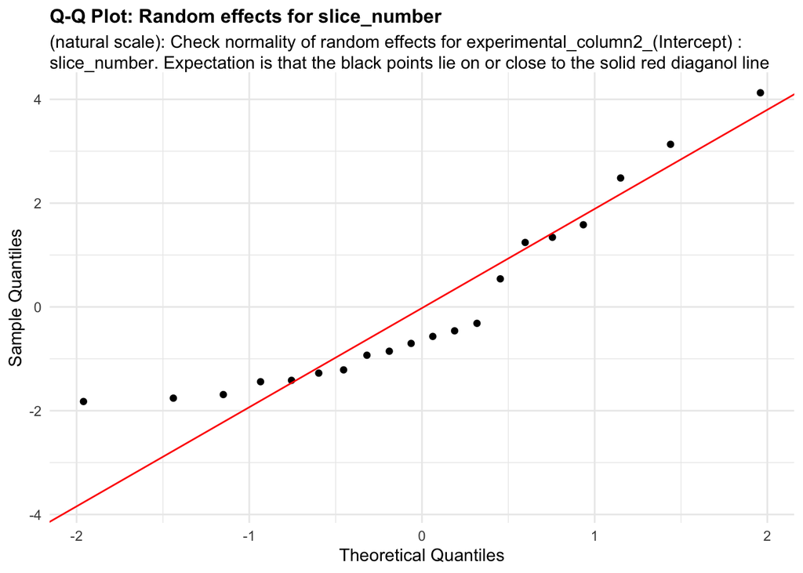

**Figure 47:** random_effects_QQ_1

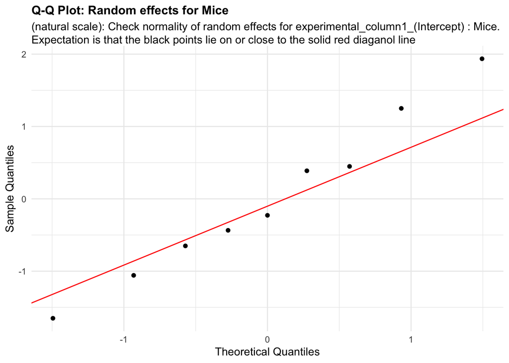

**Figure 48:** random_effects_QQ_2

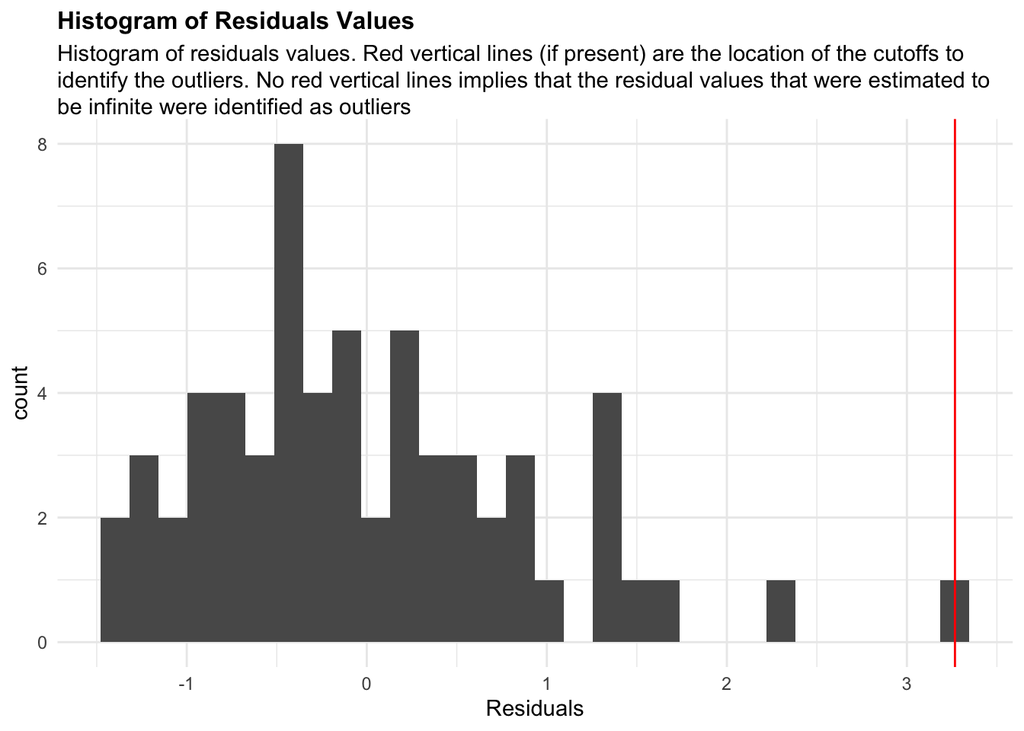

**Figure 49:** residuals_histogram

Let us look the basic QC plots for the models fit in the natural scale of the responses without the outliers.

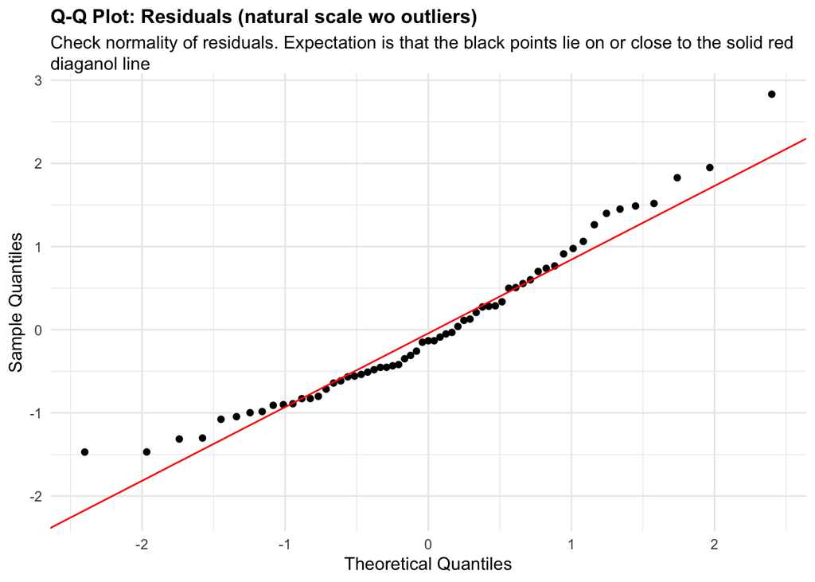

```r
plots <- diagnose_res$plots_info$natural_scale_wo_outliers$plots
captions <- diagnose_res$plots_info$natural_scale_wo_outliers$captions

for (i in seq_along(plots)) {
  print(plots[[i]])
  cat(sprintf("\n\n\n**Figure %d:** %s\n\n", plot_no, names(plots)[i]))
  plot_no <- plot_no + 1
}
```

**Figure 50:** residuals_QQ

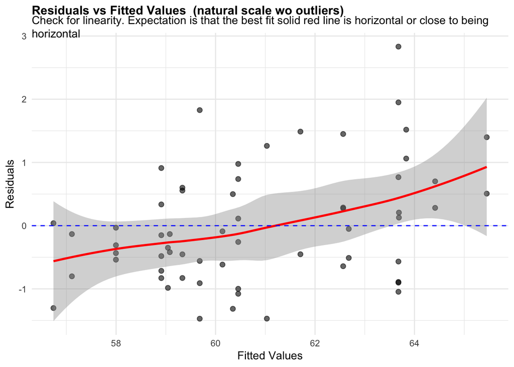

**Figure 51:** residuals_vs_fitted

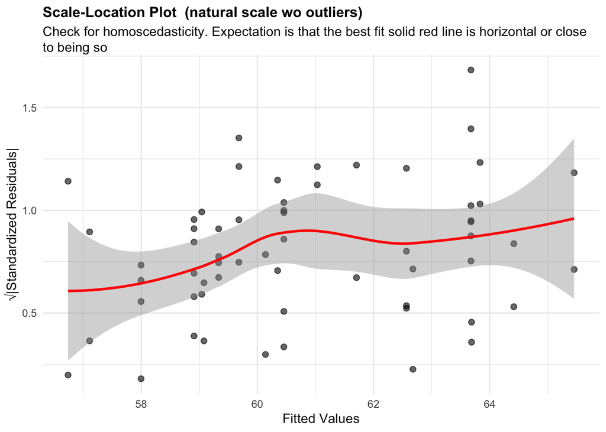

**Figure 52:** residuals_homoscedasticity

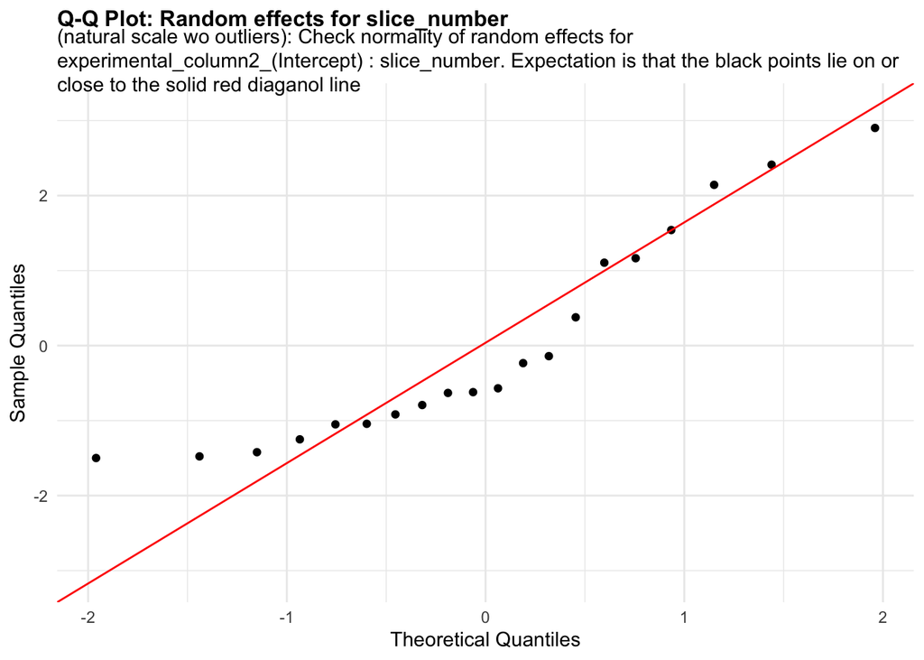

**Figure 53:** random_effects_QQ_1

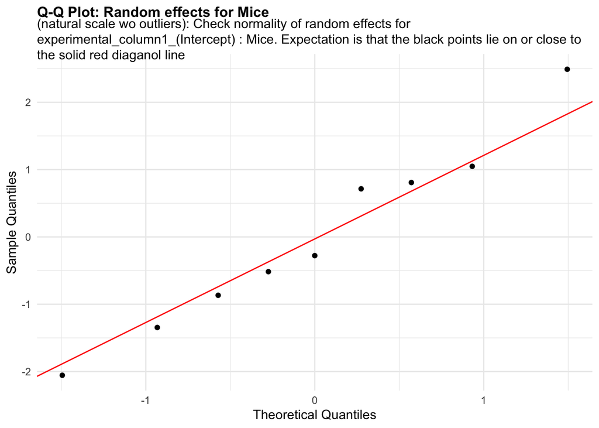

**Figure 54:** random_effects_QQ_2

Now, let us look at the same set of QC plots for models on the log-transformed responses.

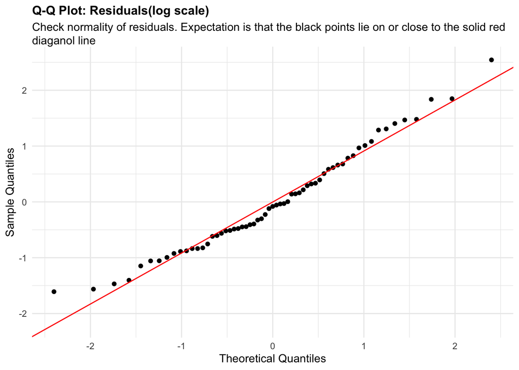

```r
plots <- diagnose_res$plots_info$log_scale$plots
captions <- diagnose_res$plots_info$log_scale$captions

for (i in seq_along(plots)) {
  print(plots[[i]])
  cat(sprintf("\n\n\n**Figure %d:** %s\n\n", plot_no, names(plots)[i]))
  plot_no <- plot_no + 1
}
```

**Figure 55:** residuals_QQ

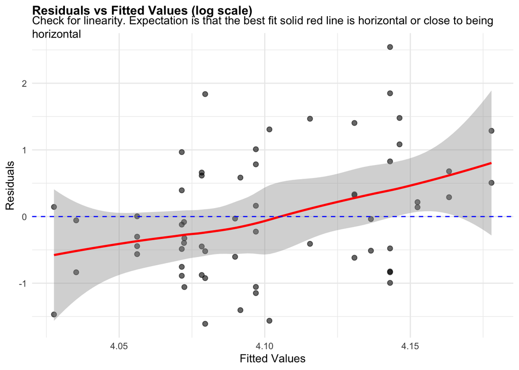

**Figure 56:** residuals_vs_fitted

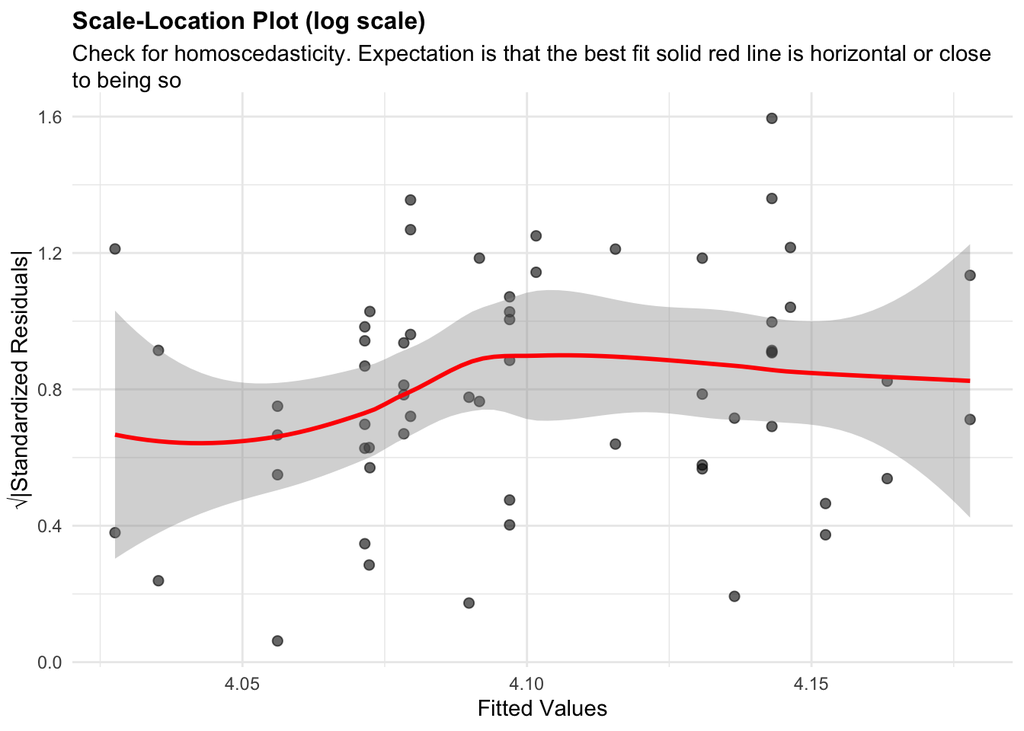

**Figure 57:** residuals_homoscedasticity

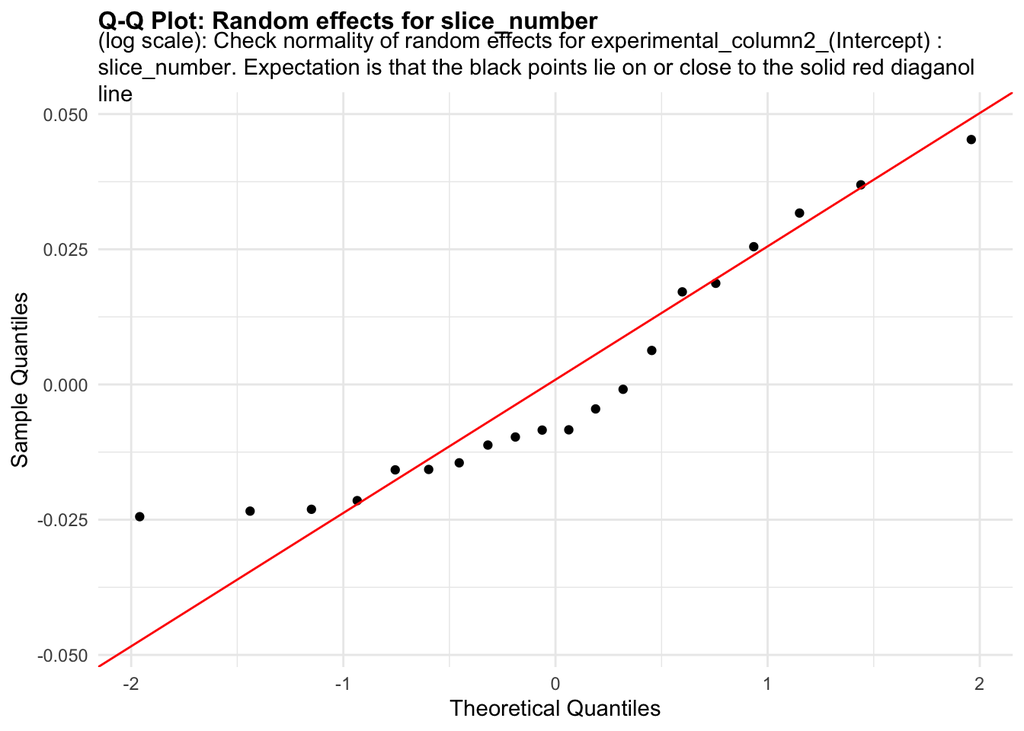

**Figure 58:** random_effects_QQ_1

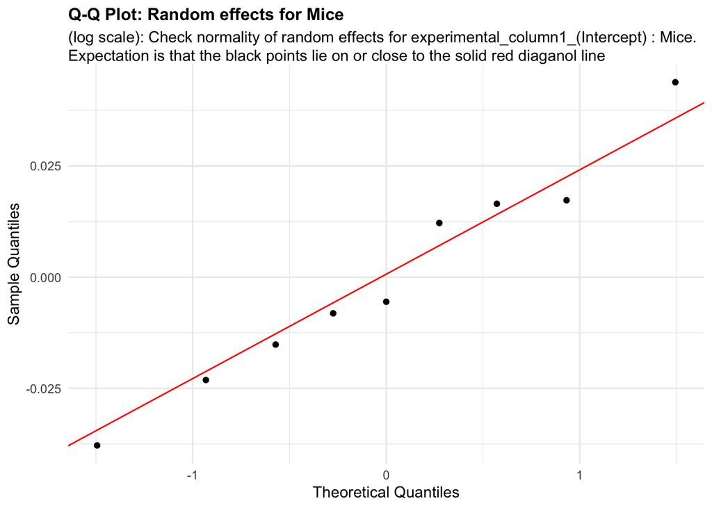

**Figure 59:** random_effects_QQ_2

We will work with the model of the electrical responses in the natural scale without outliers

The code also outputs Cook’s distance measures for each cohort and mouse that is intended to capture how influential each of these were in determining the final parameter estimates in the LMM model.

```r
##see which experimental columns correspond to which variable
print(design@experimental_columns)
```

```
## [1] "Mice"         "slice_number"
```

```r
## for each experimental column
for(i in 1:length(diagnose_res$models)) {
  for(j in 1:length(design@experimental_columns)){
    print(paste0("Cooks distance estimates for model ", diagnose_res$models[i], " and experimental factor = ", design@experimental_columns[j]))
    print(diagnose_res$cooks_result[[i]][[j]])
  }
}
```

```
## [1] "Cooks distance estimates for model Natural scale and experimental factor = Mice"
##                 [,1]
## Mouse_1  0.013139665
## Mouse_10 0.026142426
## Mouse_11 0.184524141
## Mouse_12 0.002784967
## Mouse_2  0.655865504
## Mouse_24 0.220653379
## Mouse_3  0.378843189
## Mouse_7  0.040503516
## Mouse_9  0.023118596
## [1] "Cooks distance estimates for model Natural scale and experimental factor = slice_number"
##                    [,1]
## Mouse_1_1  0.0131396653
## Mouse_10_1 0.0071996288
## Mouse_10_2 0.0137853916
## Mouse_10_3 0.0999508449
## Mouse_11_1 0.2861309687
## Mouse_11_2 0.0002917288
## Mouse_11_3 0.0091194410
## Mouse_12_1 0.0457021225
## Mouse_12_2 0.0458366056
## Mouse_2_1  0.0213101822
## Mouse_2_2  0.0997081971
## Mouse_2_3  0.0023939909
## Mouse_2_4  0.0029773914
## Mouse_24_1 0.0063247041
## Mouse_24_2 0.1036203692
## Mouse_3_1  0.1178897419
## Mouse_3_2  0.0784479575
## Mouse_7_1  0.0405035157
## Mouse_9_1  0.0047022925
## Mouse_9_2  0.0310547829
## [1] "Cooks distance estimates for model Natural scale wo outliers and experimental factor = Mice"
##                 [,1]
## Mouse_1  0.011654043
## Mouse_10 0.044525471
## Mouse_11 0.073455391
## Mouse_12 0.002492916
## Mouse_2  0.901770124
```

[output cut: 44 more lines]

```
## Mouse_11_2 0.0005309279
## Mouse_11_3 0.0059155822
## Mouse_12_1 0.0617527941
## Mouse_12_2 0.0577375323
## Mouse_2_1  0.0172482456
## Mouse_2_2  0.0874707392
## Mouse_2_3  0.0015288338
## Mouse_2_4  0.0040681640
## Mouse_24_1 0.0011938735
## Mouse_24_2 0.0861510512
## Mouse_3_1  0.1172056492
## Mouse_3_2  0.0614441192
## Mouse_7_1  0.0459538006
## Mouse_9_1  0.0031276265
## Mouse_9_2  0.0401249687
```

Mouse_2 appears to be an outlier based on its cook’s distance estimate (of 0.90) from the natural scale without outliers model and a 4/n=4/9=0.44 threshold.

We will therefore drop all observations from Mouse_2.

```r
data_update <- diagnose_res$Data_updated
data_update %<>% filter(Mice != "Mouse_2")
design_update <- design
design_update@response_column %<>% paste0(., "_noOutlier")
diagnose_res_update <- diagnoseDataModel(data_update, design_update, model)
```

```
## [1] "No outlier detected from the raw Data"
```

```
## [1] "No outlier detected from the raw Data"
```

To identify all the models fit to the data

```r
print(diagnose_res_update$models)
```

```
## [1] "Natural scale" "Log scale"
```

We see that two models were fit to this data - one in the natural scale of negative_action_potential_mV, other in the log scale.

Let us look the basic QC plots for the models fit in the natural scale of the responses.

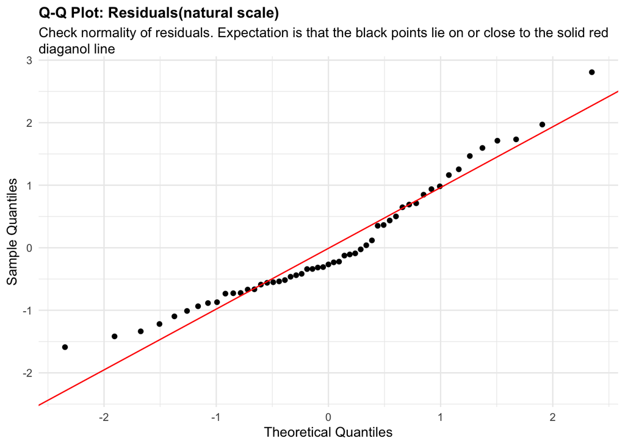

```r
plots <- diagnose_res_update$plots_info$natural_scale$plots
captions <- diagnose_res_update$plots_info$natural_scale$captions

for (i in seq_along(plots)) {
  print(plots[[i]])
  cat(sprintf("\n\n\n**Figure %d:** %s\n\n", plot_no, names(plots)[i]))
  plot_no <- plot_no + 1
}
```

**Figure 60:** residuals_QQ

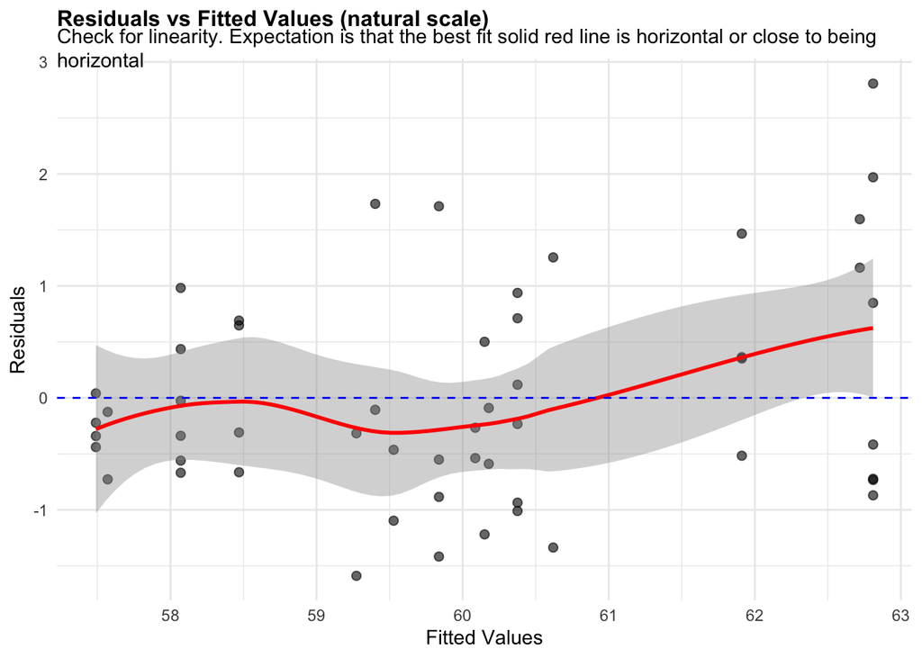

**Figure 61:** residuals_vs_fitted

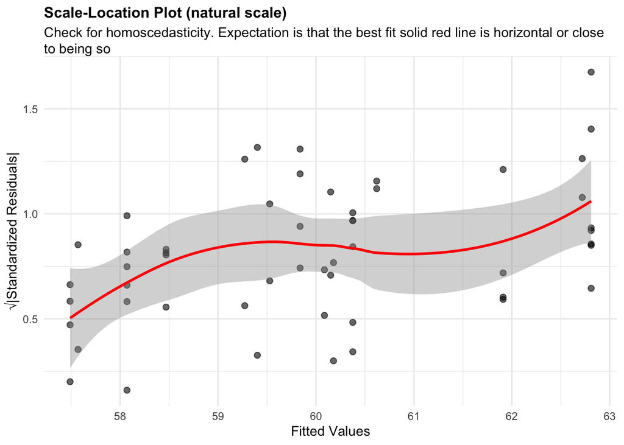

**Figure 62:** residuals_homoscedasticity

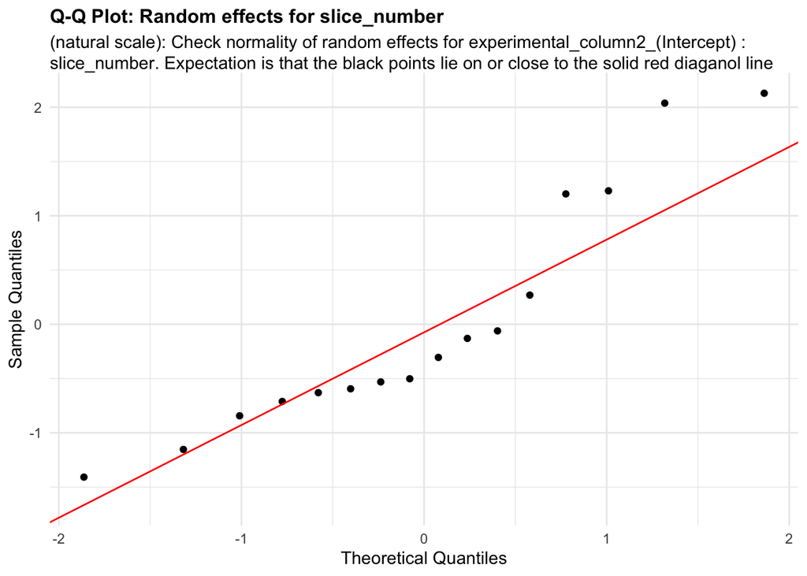

**Figure 63:** random_effects_QQ_1

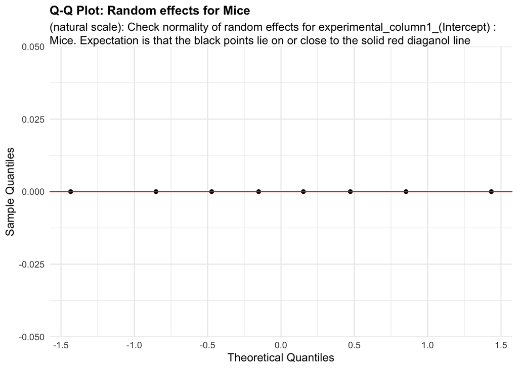

**Figure 64:** random_effects_QQ_2

Let us look the basic QC plots for the models fit in the log scale of the responses.

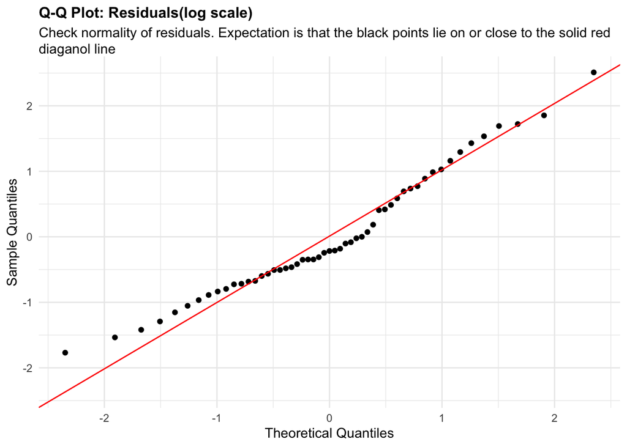

```r
plots <- diagnose_res_update$plots_info$log_scale$plots
captions <- diagnose_res_update$plots_info$log_scale$captions

for (i in seq_along(plots)) {
  print(plots[[i]])
  cat(sprintf("\n\n\n**Figure %d:** %s\n\n", plot_no, names(plots)[i]))
  plot_no <- plot_no + 1
}
```

**Figure 65:** residuals_QQ

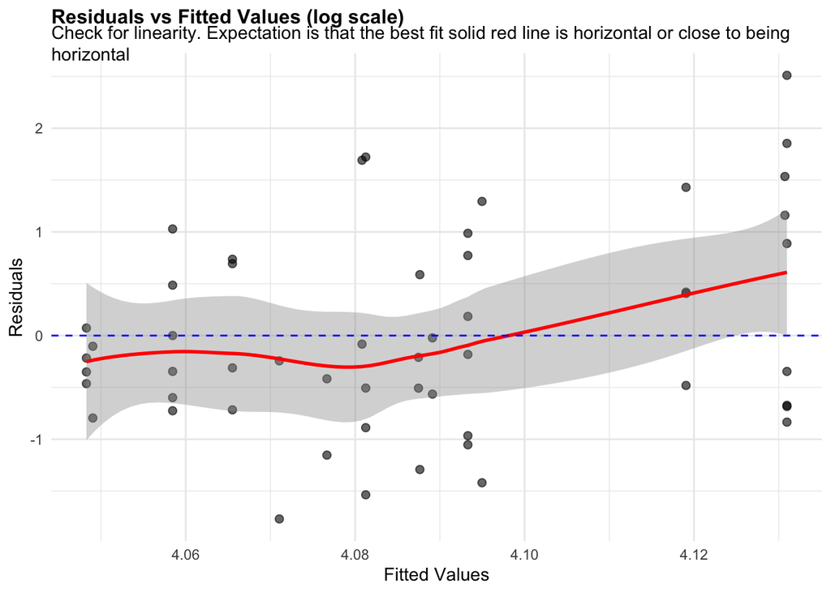

**Figure 66:** residuals_vs_fitted

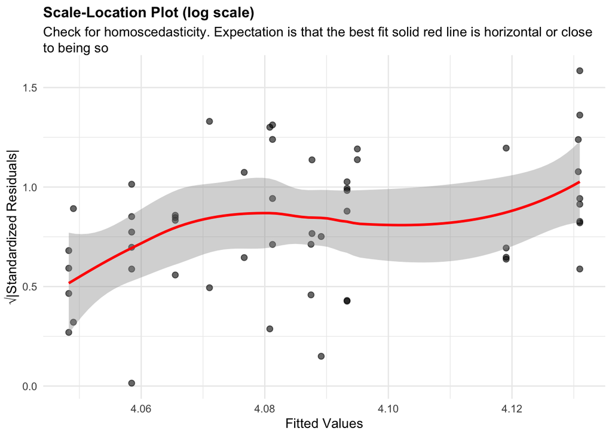

**Figure 67:** residuals_homoscedasticity

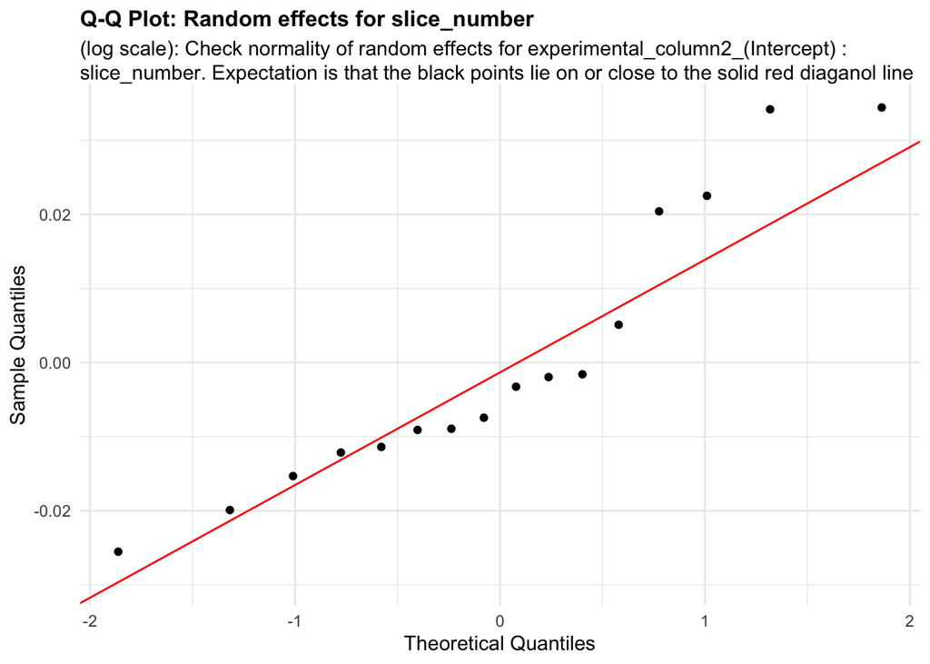

**Figure 68:** random_effects_QQ_1

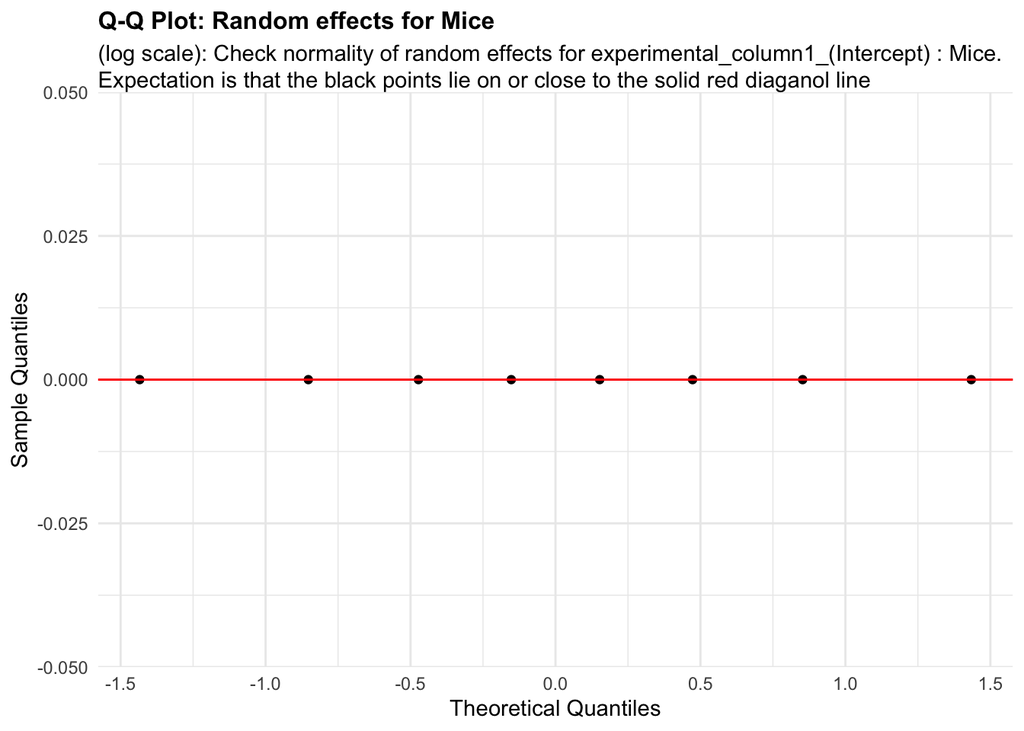

**Figure 69:** random_effects_QQ_2

It does not look like the log transformation resulted significantly changed how well the model assumptions were being met. We will estimate the association of genotype using the responses in their natural scale.

```r
estimate_res <- getEstimatesOfInterest(data, design, model)
```

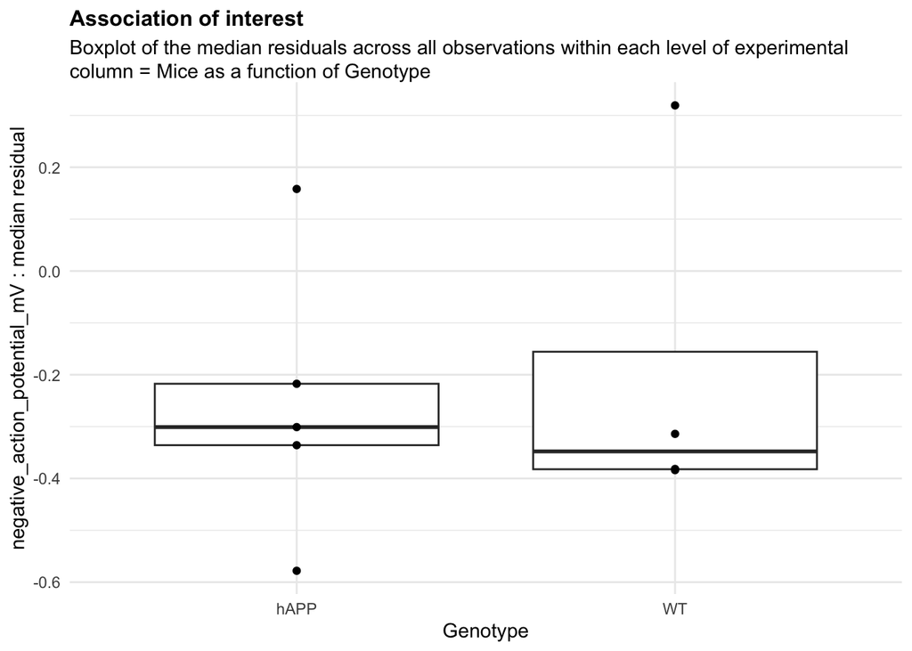

```r
print(estimate_res[[1]])
```

```
## Linear mixed model fit by REML. t-tests use Satterthwaite's method [
## lmerModLmerTest]
## Formula: response_column ~ condition_column + (1 | experimental_column1) +
##     (1 | experimental_column2)
##    Data: fixed_global_variable_data
##
## REML criterion at convergence: 429.2
##
## Scaled residuals:
##     Min      1Q  Median      3Q     Max
## -1.3970 -0.6443 -0.1594  0.4738  3.2670
##
## Random effects:
##  Groups               Name        Variance Std.Dev.
##  experimental_column2 (Intercept) 10.646   3.263
##  experimental_column1 (Intercept)  5.427   2.330
##  Residual                         56.462   7.514
## Number of obs: 62, groups:  experimental_column2, 20; experimental_column1, 9
##
## Fixed effects:
##                    Estimate Std. Error      df t value Pr(>|t|)
## (Intercept)         60.7603     1.9892  6.0708  30.545 7.04e-08 ***
## condition_columnWT   0.1541     2.9860  6.4725   0.052     0.96
## ---
## Signif. codes:  0 '***' 0.001 '**' 0.01 '*' 0.05 '.' 0.1 ' ' 1
##
## Correlation of Fixed Effects:
##             (Intr)
## cndtn_clmWT -0.666
```

This is not significant at all. How many mice do we need to have 80% power to estimate the observed difference?

```r
power_param@target_columns <- "Mice"
power_param@effect_size <- 7
power_res <- calculatePower(data, design, model, power_param)
```

```
##
## [1] "_________________________________Effect size of the condition_column is now 7"
```

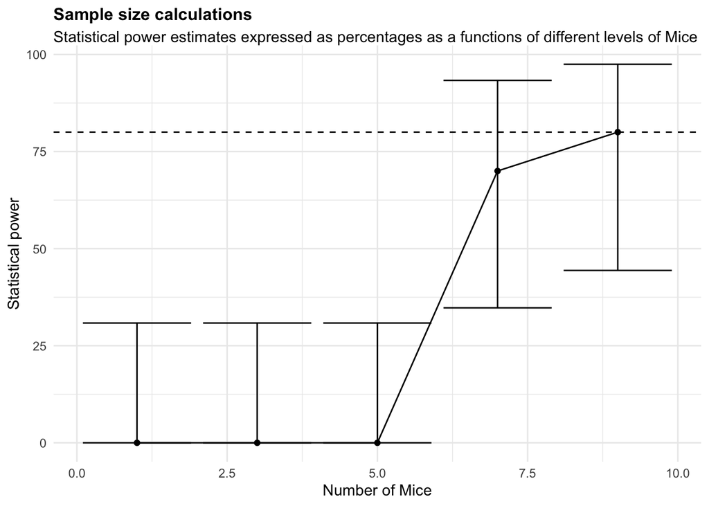

```r
print(power_res$plots)
```

```r
power_param@target_columns <- "slice_number"
power_res_slice <- calculatePower(data, design, model, power_param)
```

```
##
## [1] "_________________________________Effect size of the condition_column is now 7"
```

```r
print(power_res_slice)
```

```
## $plots
## $plots[[1]]
```

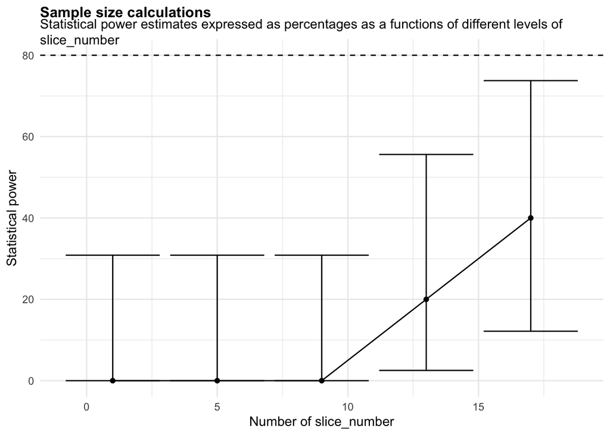

```
##
##
## $captions
## [1] "Statistical power estimates expressed as percentages as a functions of different levels of slice_number"
```

# Understanding simulations to estimate the power

`RMeDPower2` is designed to simulate the effect of variability of the responses which could come from differences in the processing batch, plates or cell lines on the responses of interest the cell assay data (described above for exampel). There are several ways to assess the impact of different choices for the experimental variables in this package as outlined below.

First, a user can assess how increasing the number of independent experiments affects power. For example, if a user has a pilot dataset that consists of 3 experimental batches that each contain 2 plates, expanding this dataset two-fold would have the effect of simulating 6 experiments with a total of 12 plates (Figure @ref(fig:exp) ).

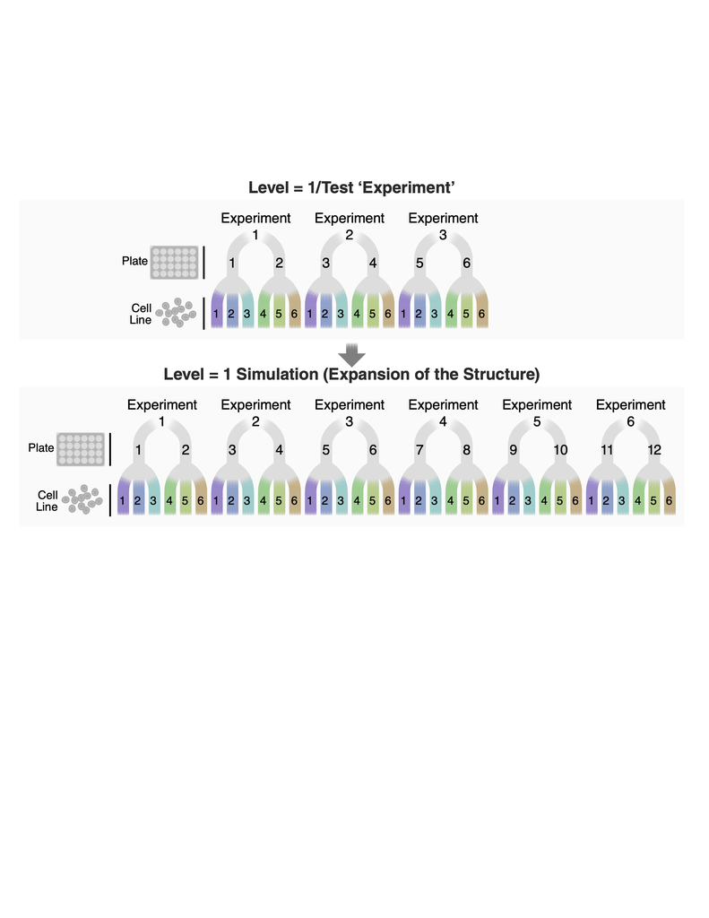

Example of RMeDPower’s simulation of experimental variability for ‘experiment’ for the power analysis. If level=1 is set, RMeDPower simulates the effect of adding in additional experiments by inheriting the experimental design structure from the existing data. This describes the situation where the pilot study involves data from 3 experiments, with 2 plates used per experiment, 3 cell lines within each plate and 12 cells per cell line are assayed.

```r
template_dir="~/Gladstone Dropbox/Reuben Thomas/calcPower f1000_manuscript/Final_paper_materials/Revisions/Older Versions Tutorial//tutorial_session3/"

##load the design
design <- readDesign(paste0(template_dir,"design_cell_assay_sim1.json"))
##load the probability model
model <- readProbabilityModel(paste0(template_dir,"prob_model_sim1.json"))
##load the relevant power parameters
power_param <- readPowerParams(paste0(template_dir,"power_param_sim1.json"))

##filter out the top 5% of observations
RMeDPower_data1 %<>% filter(cell_size2 < quantile(cell_size2, 0.95))

print(design)
```

```
## An object of class "RMeDesign"
## Slot "response_column":
## [1] "cell_size2"
##
## Slot "covariate":
## NULL
##
## Slot "condition_column":
## [1] "classification"
##
## Slot "condition_is_categorical":
## [1] TRUE
##
## Slot "experimental_columns":
## [1] "experiment" "line"
##
## Slot "crossed_columns":
## [1] "line"
##
## Slot "total_column":
## NULL
##
## Slot "outlier_alpha":
## [1] 0.05
##
## Slot "na_action":
## [1] "complete"
##
## Slot "include_interaction":
## [1] NA
##
## Slot "random_slope_variable":
## NULL
##
## Slot "covariate_is_categorical":
## [1] NA
```

```r
print(model)
```

```
## An object of class "ProbabilityModel"
## Slot "error_is_non_normal":
## [1] FALSE
##
## Slot "family_p":
## NULL
```

```r
print(power_param)
```

```
## An object of class "PowerParams"
## Slot "target_columns":
## [1] "experiment"
##
## Slot "power_curve":
## [1] 1
##
## Slot "nsimn":
## [1] 10
##
## Slot "levels":
## [1] 1
##
## Slot "max_size":
## NULL
##
## Slot "alpha":
## [1] 0.05
##
## Slot "breaks":
## NULL
##
## Slot "effect_size":
## NULL
##
## Slot "icc":
## NULL
```

The first step involves running a diagnosis of the data and the model.

```r
diagnose_res <- diagnoseDataModel(RMeDPower_data1, design, model)
design_update <- design
data_update <- diagnose_res$Data_updated
print(colnames(data_update))
```

```
##  [1] "cell_size2_logTransformed" "experiment"
##  [3] "line"                      "classification"
##  [5] "cell_size1"                "cell_size2"
##  [7] "cell_size3"                "cell_size4"
##  [9] "cell_size5"                "cell_size6"
```

```r
design_update@response_column <-  "cell_size2_logTransformed"
```

We can now perform sample-size estimations for the effects of increasing the number of experimental batches.

```r
##calculate power
power_res <- calculatePower(data_update, design_update, model, power_param)
```

[output not shown]

In a similar context, users can evaluate power for a given number of experiments. To do this, we assign a value corresponding to the number of experiments to ‘max_size’ and set ‘power_curve’ to 0. We can set the ‘output’ variable to specify the output file name.

```r
template_dir="~/Gladstone Dropbox/Reuben Thomas/calcPower f1000_manuscript/Final_paper_materials/Revisions/Older Versions Tutorial//tutorial_session3/"

##load the relevant power parameters
power_param <- readPowerParams(paste0(template_dir,"power_param_sim3.json"))

print(power_param)
```

```
## An object of class "PowerParams"
## Slot "target_columns":
## [1] "experiment"
##
## Slot "power_curve":
## [1] 0
##
## Slot "nsimn":
## [1] 10
##
## Slot "levels":
## [1] 1
##
## Slot "max_size":
## [1] 15
##
## Slot "alpha":
## [1] 0.05
##
## Slot "breaks":
## NULL
##
## Slot "effect_size":
## NULL
##
## Slot "icc":
## NULL
```

```r
##calculate power
power_res <- calculatePower(data_update, design_update, model, power_param)
```

```
## Power for predictor 'condition_column', (95% confidence interval):
##       90.00% (55.50, 99.75)
##
## Test: Likelihood ratio
##
## Based on 10 simulations, (0 warnings, 0 errors)
## alpha = 0.05, nrow = 12290
##
## Time elapsed: 0 h 0 m 3 s
##
## nb: result might be an observed power calculation
```

```r
set.seed(12345)
##observed differences of means = 0.03072
power_param@max_size <- 8
power_param@target_columns <- "experiment"
power_param@levels <- 1
power_param@power_curve <- 0
power_param@effect_size <- 0.03072
calculatePower(data_update, design_update, model, power_param)
```

```
##
## [1] "_________________________________Effect size of the condition_column is now 0.03072"
##
## Power for predictor 'condition_column', (95% confidence interval):
##       70.00% (34.75, 93.33)
##
## Test: Likelihood ratio
##
## Based on 10 simulations, (0 warnings, 0 errors)
## alpha = 0.05, nrow = 6428
##
## Time elapsed: 0 h 0 m 1 s
```

```r
set.seed(12345)
##asssumed difference of means = 0.02
power_param@max_size <- 8
power_param@target_columns <- "experiment"
power_param@levels <- 1
power_param@power_curve <- 0
power_param@effect_size <- 0.02
calculatePower(data_update, design_update, model, power_param)
```

```
##
## [1] "_________________________________Effect size of the condition_column is now 0.02"
##
## Power for predictor 'condition_column', (95% confidence interval):
##       50.00% (18.71, 81.29)
##
## Test: Likelihood ratio
##
## Based on 10 simulations, (0 warnings, 0 errors)
## alpha = 0.05, nrow = 6428
##
## Time elapsed: 0 h 0 m 2 s
```

We can also test the power of two experimental variables by assigning a vector of variable names to ‘target_columns’.

```r
template_dir="~/Gladstone Dropbox/Reuben Thomas/calcPower f1000_manuscript/Final_paper_materials/Revisions/Older Versions Tutorial//tutorial_session3/"

power_param <- readPowerParams(paste0(template_dir,"power_param_sim5.json"))

print(power_param)
```

```
## An object of class "PowerParams"
## Slot "target_columns":
## [1] "experiment" "line"
##
## Slot "power_curve":
## [1] 1
##
## Slot "nsimn":
## [1] 10
##
## Slot "levels":
## [1] 1 0
##
## Slot "max_size":
## [1]   9 142
##
## Slot "alpha":
## [1] 0.05
##
## Slot "breaks":
## NULL
##
## Slot "effect_size":
## NULL
##
## Slot "icc":
## NULL
```

```r
##calculate power
power_res <- calculatePower(data_update, design_update, model, power_param)
```

[output not shown]

Our power simulations depend on the variance components estimated from the input dataset. However, in some cases there may not be enough data to estimate the variance component. For example, the pilot data might have only a single category for ‘experimental batch’, ‘plate’ or ‘line’. When this occurs, the user needs to provide ICC values. These values can be estimated from another dataset for which the variance components are assumed to be similar to those inherent for the new response being considered in the input dataset. ICC can be estimated by taking the ratio between the variance estimates using the following formula:

$$ICC_i=\frac{V_i}{∑_{j∈S}V_i+e}$$
where V_i represents the variance of the random effect linked to experimental variable (e.g., experimental batch, plate or cell-line) i, and epsilon represents the variance of the residual error. S represents all the modeled sources of variability of the response under consideration. We will test this scenario using the example RMeDPower_data2 with only single experiment and cell line. To test power in scenarios with varying number of experiments, we set the ‘icc’ parameter to 0.8, 0.05, 0.05.

```r
template_dir="~/Gladstone Dropbox/Reuben Thomas/calcPower f1000_manuscript/Final_paper_materials/Revisions/Older Versions Tutorial//tutorial_session3/"

##load the design
design <- readDesign(paste0(template_dir,"design_cell_assay_sim6.json"))
##load the probability model
model <- readProbabilityModel(paste0(template_dir,"prob_model_sim6.json"))
##load the relevant power parameters
power_param <- readPowerParams(paste0(template_dir,"power_param_sim6.json"))

#print(design)
#print(model)
print(power_param)
```

```
## An object of class "PowerParams"
## Slot "target_columns":
## [1] "experiment"
##
## Slot "power_curve":
## [1] 1
##
## Slot "nsimn":
## [1] 10
##
## Slot "levels":
## [1] 1
##
## Slot "max_size":
## NULL
##
## Slot "alpha":
## [1] 0.05
##
## Slot "breaks":
## NULL
##
## Slot "effect_size":
## NULL
##
## Slot "icc":
## [1] 0.80 0.05 0.05
```

```r
##calculate power
power_res <- calculatePower(RMeDPower_data2, design, model, power_param)
```

[output not shown]

Alternatively, a user can assess how increasing the number of plates per experiment affects power. In the case where there are two experiments that each contain two plates, the user can double the number of plates used per experiment. In this way, the user can simulate how the statistical power changes as a result of increasing the number of plates used per experiment rather than increasing the number of experimental batches (Figure @ref(fig:plate)).

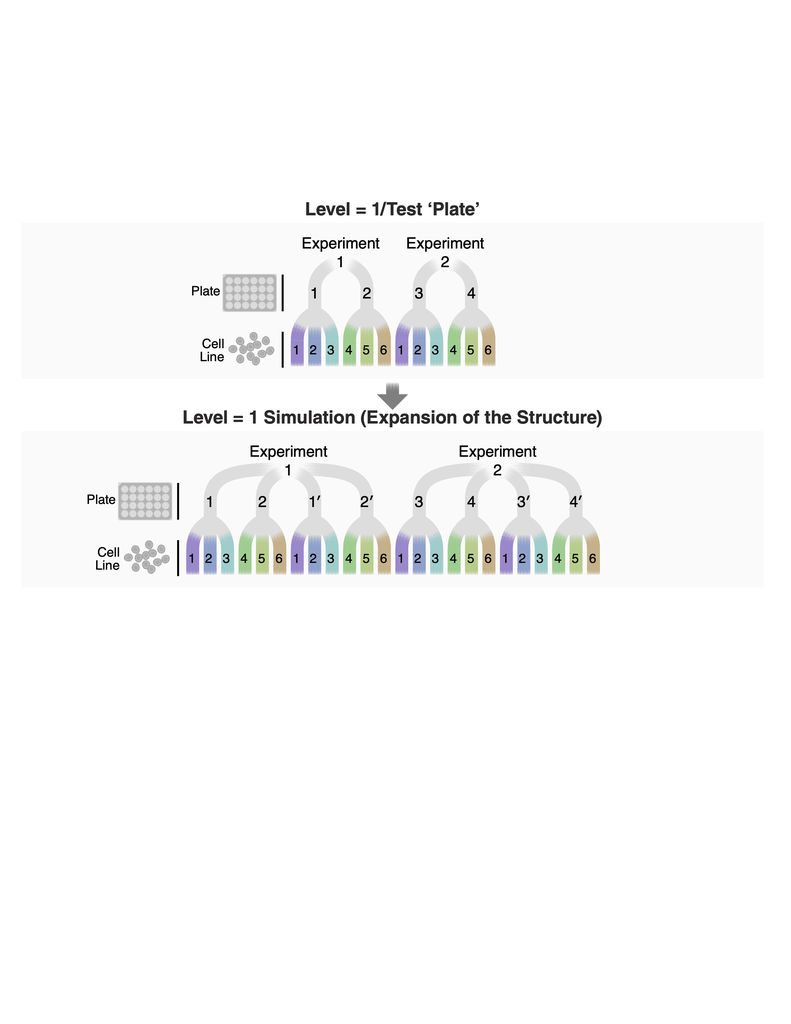

Example of RMeDPower’s simulation of plate variability for ‘plate’ power analysis. If level=1 is set, RMeDPower simulates new plates by inheriting the experimental design structure from the existing data.

In a third example, a user can examine the effect of expanding the number of cell lines within each experiment affects power (Figure @ref(fig:line)). This would capture the effect of increasing the number of cells assayed as a consequence of having more cell lines.

Example of RMeDPower’s simulation of cell line variability for ‘cell line’ power analysis. If level=1 is set, RMeDPower simulates new cell lines by inheriting the experimental design structure from the existing data.

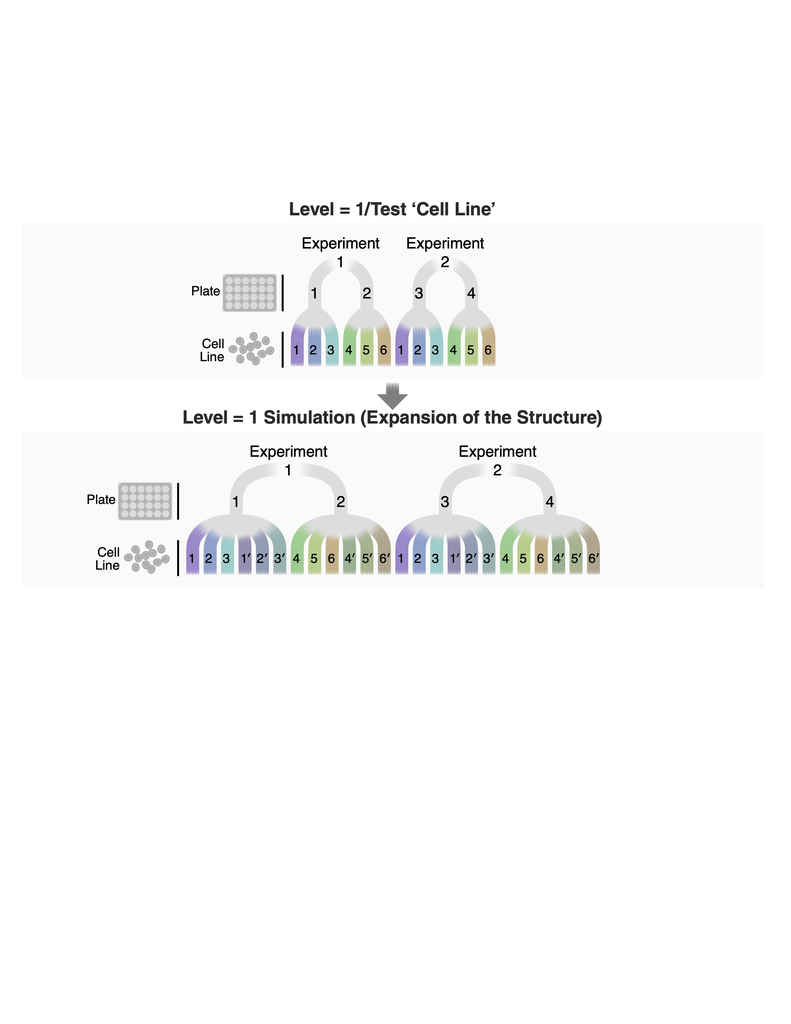

Alternatively, one might want to assess the effect of increasing the total number of cells by increasing the number of cells per cell line (Figure @ref(fig:lineCell)).